```python
# Run this cell first!
import pandas as pd
import numpy as np
%matplotlib inline
import matplotlib.pyplot as plt
import seaborn as sns
from scipy import stats
from sklearn import model_selection, linear_model, ensemble, preprocessing, neural_network, metrics
```

# Modelling Yearly Healthcare Costs

The ultimate goal of this project is to create a model to better predict yearly healthcare costs for our self-funded healthcare clients (specifically hospitals). More specifically, the model will use 36 months of claims and expense report data to predict total cost for the following year. **Due to limitations in the scope of the data available, the specifications of the central question driving this analysis, and my own skills/knowledge as an amateur data scientist the model created in this project is more of a proof-of-concept than a full-fledged, deployment-ready model for predicting yearly healthcare costs. While the model is able to predict costs from historical data with sometimes striking accuracy (i.e. within +/- \\$10 PEPM) it ultimately fails to predict costs with consistent accuracy—as in it is occasionally \\$200+ off. That is not to say the time spent on this project was a waste; rather, this project, again, serves as proof that more advanced analytics can prove to be an incredibly valuable asset to the BUAD team. At the end of the day, previous claims experience is not enough to capture the volatility/variance of yearly healthcare costs. Given more time, I would dig deeper into the data available on Mede for our self-insured clients that could help better predict costs; but, alas, my time here has come to an end. In the following report, I'll walk through my analysis and provide a deeper, more thorough analysis/debrief in the Conclusion Section at the end of this report.**

*Note: Due to certain html tags utilized in this report, the html file is best viewed on a browser other than Firefox*.

## Introduction

For any underwriting team, calculating renewal projections can be a frustratingly difficult process. The main concern posed to underwriters is the volatility of claims experience data. Year-by-year and even month-by-month breakdowns of claims experience data yield often inconsistent numbers with frustratingly high variance. An experienced underwriter will take their industry knowledge and apply it to historical claims experience data to mitigate the impact of volatility on their renewal projections. This project aims to leverage Machine Learning models to aid the underwriter in the renewal projection process. The model will be built using data from a variety of healthcare clients. A full list is included below:

- Antelope Valley Hospital (1/1 Start | Data from 1/11 - 5/22)
- Avanti/Pipeline (1/1 Start | Data from 1/14 - 12/21)
- Beverly Hospital (1/1 Start | Data from 1/17 - 6/22)
- CHA Hollywood Presbyterian Medical Center (1/1 Start | Data from 1/18 - 6/22)
- Children's Hospital Los Angeles (7/1 Start | Data from 7/17 - 6/22)
- Dameron Hospital (1/1 Start | Data from 1/11 - 6/22)
- Enloe Medical Center (7/1 Start | Data from 7/12 - 6/19)
- Epic Medical Group (10/1 Start | Data from 10/15 - 9/18)
- Fairchild Medical Center (7/1 Start | Data from 7/13 - 6/22)
- Henry Mayo Newhall Hospital (3/1 Start | Data from 3/13 - 2/22)
- Huntington Memorial Hospital (1/1 Start | Data from 1/15 - 6/22)
- Marshall Medical Center (11/1 Start | Data from 11/13 - 10/16)
- Northern Inyo Hospital (1/1 Start | Data from 1/18 - 6/22)
- Prime Healthcare Services (1/1 Start | Data from 1/11 - 6/22)
- Prospect Medical Holdings (1/1 Start | Data from 1/13 - 12/20)
- Salinas Valley Memorial Healthcare System (1/1 Start | Data from 1/18 - 12/21)
- Tahoe Forest Health System (1/1 Start | Data from 1/15 - 6/22)
- Torrance Health Association (1/1 Start | Data from 1/11 - 6/22)

The data for this project was gathered from Monthly Claims and Expense Reports (C&Es) for each of the clients enumerated above. A more detailed description of the exact data pulled will be included in the Data Section below.

Ultimately, the model will use 36 months of data to predict the next year's total healthcare cost for Keenan's self-insured healthcare clients. More specifically, it will use the actual monthly PEPM cost to predict the following year's total healthcare cost.

As an aside, there is often a misconception surrounding Data Science that the point of creating Machine Learning models is to completely strip away the human element; however the model is merely performing a series of Linear Algebra calculations that must be made sense of within the greater context of the insurance space. Moreover, it is alongside expert feedback/insight that the model was created—it is inherently human as much as it is automated. In light of that, I want to thank both Kyle for providing that expert insight throughout the process and the entire BUAD team for helping me learn more about employer-sponsored health plans and the ins-and-outs of the space—without all of you this project could not have come togeether.

### The Standard Renewal Worksheet

It is worth noting that the intent of this model is not to completely replace the current processes for calculating renewal projections. Rather, it is intended to be used as a supplement with the standard projection processes to help confirm the reliability of calculated renewal projections and to help prevent volatility from blowing up a renewal projection. Some of the features included in the standard renewal worksheet are incorporated into this model—albeit not in the same way.

**Trend Factor**

Although not explicitly included in the model as a predicitve feature, the Trend Factor (both Medical and Rx) is accounted for in the model's predictions. Fundamentally, the model identifies historical patterns and projects them into the future; as such, the Trend Factor--accounting for the increasing cost of medical treatment--is included in the model's predictions.

**Administration Fees**

The administration fees are included within the Adjusted Paid Claims feature used to train the model.

### Basic Methodology

Since the goal is to (or at least attempt to) predict annual healthcare costs, the granularity of the data will be yearly (i.e. each row will represent a **Plan Year** and not a standard year). However, considering the ultimate goal is to predict healthcare costs from 36 months of previous data, the granularity of the data used to train any/all models will be 36 months (i.e. each row will represent one 36-month period).

While a more detailed description of the specific methodology will be provided within each section of the report, the basic methodology is as follows:

**Exploratory Data Analysis (EDA)**

Exploratory Data Analysis is the critical first-step to building Machine Learning models. By exploring the provided data to determine interesting or unusual relationships between variables or empirically confirming expected relationships between data, this stage ensures that the foundation that the model is built upon is solid. This section will focus particularly on visualizing the relationship between PEPM Cost and PMPM Cost and working to create distributions representative of certain subsets of the data that will be crucial to the process of data formation.

**Modelling**

Once certain relationships have been identified and/or confirmed within the data, it must be transformed and manipulated so that it is adequate for model training. Specifically, more data will need to be genereated so that the sample size is sufficient. To do so, the representative distributions crafted in the previous section (representing the first four plan years for each of the clients in the data) will be sampled randomly with replacement 1000 times. A separate classification model will be used to indentify and isolate points that are prone over and underestimation which will promptly be used to train two separate linear regression models for predicting yearly healthcare costs.

*Note: The beginning of each section or subsection will contain a cell with all the Python user-defined functions referenced in the section. These are not to be read as text.*

### Note On Technical Specificity

Throughout this project there is an assumption that readers will have varying degrees of familiarity with the underlying statistical theory that justifies some of the approaches taken and certain programming techniques used throughout this analysis. As such, sections discussing methodology or providing justification for the use of certain statistical methods will have descriptions at varying levels of abstraction.

## Exploratory Data Analysis (EDA)

```python
# Python user-defined functions in alphabetical order
def calculate_weighted_pepm_avg(data, plan_year):
    '''
    Given data, data, and plan year, calculates
    the year's weighted average PEPM cost
    -----
    Inputs:

    data (DataFrame) - DataFrame with data to calculate the year's
                       weighted average pepm cost

    renewal_year (int) - Int specifying the plan year to calculate
    -----
    Output:

    weighted_avg (float) - Calculated weighted average
    '''
    plan_year = data.sort_values(['Year', 'Month']).query('`Renewal Year` == @renewal_year')
    py_pepms = plan_year['PEPM'].values
    py_ee_counts = plan_year['EE Count'].values
    py_total_ee_count = sum(py_ee_counts)
    py_props = py_ee_counts / py_total_ee_count
    weighted_avg = sum(py_pepms * py_props)
    return weighted_avg

def calculate_weighted_pmpm_avg(data, plan_year):
    '''
    Given data, data, and plan year, calculates
    the year's weighted average PMPM cost
    -----
    Inputs:

    data (DataFrame) - DataFrame with data to calculate the year's
                       weighted average pepm cost

    renewal_year (int) - Int specifying the plan year to calculate
    -----
    Output:

    weighted_avg (float) - Calculated weighted average
    '''
    plan_year = data.sort_values(['Year', 'Month']).query('`Renewal Year` == @renewal_year')
    py_pepms = plan_year['PEPM'].values
    py_ee_counts = plan_year['Member Count'].values
    py_total_ee_count = sum(py_ee_counts)
    py_props = py_ee_counts / py_total_ee_count
    weighted_avg = sum(py_pepms * py_props)
    return weighted_avg
```

### Data

As noted in the Introduction, the data used for this project is an amalgamation of data from a variety of Keenan's self-funded healthcare clients. The data will be loaded in and displayed below:

```python
# Loading in the data and performing necessary data transformations
claims = pd.read_csv('Healthcare Clients.csv')
claims['PEPM'] = claims['Adjusted Total Expenses'] / claims['EE Count']
claims['PMPM'] = claims['Adjusted Total Expenses'] / claims['Member Count']
claims
```

|  | Month | Year | Plan Month | Plan Year | Total Medical Claims | Total Rx Claims | Total Paid Claims | Adjusted Total Expenses | EE Count | Member Count | Client | PEPM | PMPM |
| --- | --- | --- | --- | --- | --- | --- | --- | --- | --- | --- | --- | --- | --- |
| 0 | 1 | 2011 | 1 | 1 | 4767.00 | 195529.47 | 200296.47 | 336582.47 | 1093 | 2710 | Antelope Valley | 307.943705 | 124.200173 |
| 1 | 2 | 2011 | 2 | 1 | 492254.80 | 195997.93 | 688252.73 | 824538.73 | 1093 | 2674 | Antelope Valley | 754.381272 | 308.354050 |
| 2 | 3 | 2011 | 3 | 1 | 449411.00 | 230158.09 | 679569.09 | 816977.09 | 1102 | 2690 | Antelope Valley | 741.358521 | 303.708955 |
| 3 | 4 | 2011 | 4 | 1 | 829805.58 | 204176.23 | 1033981.81 | 1170641.81 | 1096 | 2683 | Antelope Valley | 1068.103841 | 436.318230 |
| 4 | 5 | 2011 | 5 | 1 | 675157.46 | 196067.47 | 871224.93 | 1006014.93 | 1081 | 2613 | Antelope Valley | 930.633608 | 385.003800 |
| ... | ... | ... | ... | ... | ... | ... | ... | ... | ... | ... | ... | ... | ... |
| 1572 | 2 | 2022 | 2 | 12 | 700450.75 | 291079.36 | 991530.11 | 733061.77 | 1134 | 2354 | Torrance Health | 646.438951 | 311.411117 |
| 1573 | 3 | 2022 | 3 | 12 | 1176646.24 | 241579.60 | 1418225.84 | -69428.66 | 1137 | 2366 | Torrance Health | -61.063026 | -29.344320 |
| 1574 | 4 | 2022 | 4 | 12 | 974612.44 | 236503.49 | 1211115.93 | 1344295.40 | 1139 | 2365 | Torrance Health | 1180.241791 | 568.412431 |
| 1575 | 5 | 2022 | 5 | 12 | 954969.28 | 253322.95 | 1208292.23 | 1237096.06 | 1144 | 2368 | Torrance Health | 1081.377675 | 522.422323 |
| 1576 | 6 | 2022 | 6 | 12 | 896835.62 | 307918.72 | 1204754.34 | 1338474.19 | 1144 | 2395 | Torrance Health | 1169.994921 | 558.861875 |

1577 rows × 13 columns

This is the `claims` dataset that will ultimately be used for our model. Below is a description of each feature included in `claims`:

**Month**

Month of the year represented by each row with 1 corresponding to January, 2 to February, 3 to March, etc.

**Year**

Calendar year that corresponds to the month represented by each row of data.

**Plan Month**

Specifies the month number chronologically in the client's plan year. For clients with 1/1 start dates, the `Plan Month` feature will always be equivalent to the `Month` feature. As such, this feature is significant only for clients with start dates other than 1/1.

**Plan Year**

Specifies the plan year that corresponds to the month represented by each row. Note: the values may not correspond to the true plan year for the given client; rather, they specify the plan year for all those that are within the `claims` dataset.

**Total Medical Claims**

The total amount of Medical claims paid out in the given month. This includes Domestic Hospital Claims (both IP and OP), Non-Domestic Hospital Claims (IP and OP), and Non-Hospital Medical Claims.

**Total Rx Claims**

The total amount of Rx claims paid out in the given month. This includes Domestic Rx Claims and Non-Domestic Rx Claims.

**Total Paid Claims**

The total amount of claims (Medical and Rx) paid out in the given month or the sum of `Total Medical Claims` and `Total Rx Claims`. **This does not include Stop Loss Reimbursements, Rx Rebates, or Rx Performance Guarantees**.

**Adjusted Total Expenses**

The total amount paid out in the given month. **This includes `Total Paid Claims`, Stop Loss Reimbursements, Rx Rebates, Rx Performance Guarantees, and Total Admin Fees**. These are the Monthly Claims and Expenses values from Monthly C&Es.

**EE Count**

The number of employees enrolled in the client's health plan in the given month.

**Member Count**

The number of members enrolled in the client's health plan in the given month. The vast majority of C&Es included all of the data necessary; however, some C&Es lacked monthly member counts. In such a case, the monthly Rx Member Count was substituted as an estimate for the monthly Medical Member Count. If the monthly Rx Member Count was unavailable, a multiplier was applied to the monthly EE Count to estimate the number of enrolled members each month. These monthly multipliers were the averages of the monthly EE Count multipliers for all other months for the given client.

**Client**

The name of the client corresponding to the given row of data.

**PEPM**

The per-employee-per-month cost for the given month. This is calculated as the quotient of `Adjusted Total Expenses` and `EE Count`. *Note: There were a few values < 0 which will be exlcuded from the dataset entirely*.

**PMPM**

The per-member-per-month cost for the given month. This is calculated as the quotient of `Adjusted Total Expenses` and `Member Count`. *Note: There were a few values < 0 which will be exlcuded from the dataset entirely*.

### Data Visualization

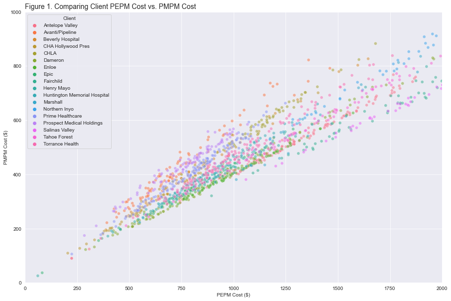

```python
# Figure 1. Comparing Client PEPM Cost vs. PMPM Cost
plt.figure(figsize=(15, 10))
sns.set_style('darkgrid')
sns.scatterplot(data=claims, x='PEPM', y='PMPM', hue='Client', alpha=0.5)
plt.title('Figure 1. Comparing Client PEPM Cost vs. PMPM Cost', loc='left', fontdict={'fontsize': 14})
plt.xlabel('PEPM Cost ($)')
plt.ylabel('PMPM Cost ($)')
plt.xlim(0, 2000)
plt.ylim(0, 1000)
plt.show()
```

*Note: For readability's sake **Figure 1** limits PEPM Cost to \\$2000 and PMPM Cost to \\$1000.*

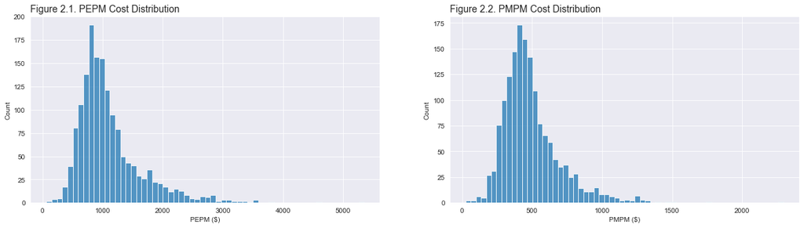

```python
plt.figure(figsize=(20, 5))

# Figure 2.1. PEPM Cost Distribution
plt.subplot(1, 2, 1)
sns.histplot(data=claims.query('PEPM > 0'), x='PEPM')
plt.xlabel('PEPM ($)')
plt.title('Figure 2.1. PEPM Cost Distribution', loc='left', fontdict={'fontsize': 14})

# Figure 2.2. PMPM Cost Distribution
plt.subplot(1, 2, 2)
sns.histplot(data=claims.query('PMPM > 0'), x='PMPM')
plt.xlabel('PMPM ($)')
plt.title('Figure 2.2. PMPM Cost Distribution', loc='left', fontdict={'fontsize': 14})
plt.show()
```

**Figures 1**, **2.1**, and **2.2** all effectively demonstrate what may seem intuitive: that PEPM Cost and PMPM Cost are highly correlated. **Figure 1**, in essence, visualizes the EE/Member Count multiplier discussed in the Data Section above. Within each client, the points virtually form a line--indicating that the EE/Member Count multiplier does not fluctuate dramatically from month-to-month for any given client. Likewise, because the spread of the points overall is relatively narrow, it becomes apparent that the EE/Member Count multiplier does not fluctuate much between clients either. **Figures 2.1** and **2.2** (taken together) communicate a similar notion. Here, both histograms display distributions that seem incredibly similar in shape. While the scales of both the x- and y-axes differ between plots, the overall shape of the distributions remains the same—suggesting the two features seem to be correlated.

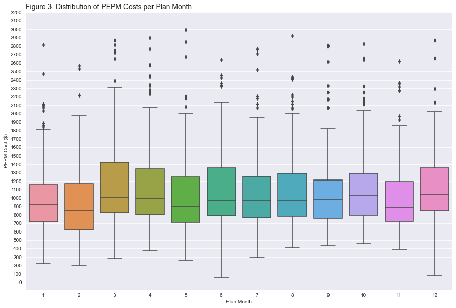

```python
# Figure 3. Distribution of PEPM Costs per Plan Month
plt.figure(figsize=(15, 10))
sns.boxplot(data=claims.query('PEPM > 0 and PEPM < 3000'), x='Plan Month', y='PEPM')
plt.yticks(np.arange(0, 3300, 100))
plt.ylabel('PEPM Cost ($)')
plt.title('Figure 3. Distribution of PEPM Costs per Plan Month', loc='left', fontdict={'fontsize': 14})
plt.show()
```

**Figure 3** is particularly encouraging. In previous iterations of this project, a model was created with data just from Huntington Memorial Hospital. While the model worked, because of the extremely little data available, tempering volatility was an incredibly frustrating process. Here, while that same data is incorporated in the `claims` dataset, the sheer volume of data prevents outliers from hampering the data's utility. As a result, the mean of each `Plan Month` PEPM Cost distribution is relatively stable with similarly stable IQRs (middle 50%). Most of the outliers occur on the higher end which is to be expected.

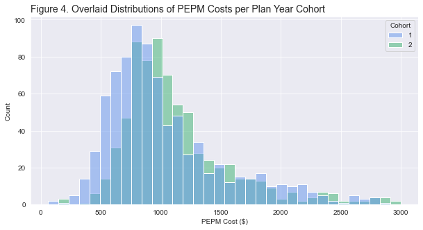

```
Statistic: 4.298020532918551
p-value: 1.8288907954969783e-05
Cohort 1 Proportion: 0.533
Cohort 2 Proportion: 0.467
```

```python
# Figure 4. Overlaid Distributions of PEPM Cost per Plan Year Cohort
claims_copy = claims.copy()
claims_copy['Cohort'] = [2 if year >= 5 else 1 for year in claims_copy['Plan Year'].values]
plt.figure(figsize=(10, 5))
sns.histplot(data=claims_copy.query('PEPM > 0 and PEPM < 3000'), x='PEPM', hue='Cohort', palette=['cornflowerblue', 'mediumseagreen'])
plt.xlabel('PEPM Cost ($)')
plt.title('Figure 4. Overlaid Distributions of PEPM Costs per Plan Year Cohort', loc='left', fontdict={'fontsize': 14})
plt.show()
cohort1 = claims_copy.query('Cohort == 1')['PEPM'].values
cohort2 = claims_copy.query('Cohort == 2')['PEPM'].values
score = stats.ttest_ind(cohort2, cohort1)
print(f'Statistic: {score[0]}')
print(f'p-value: {score[1]}')
print(f'Cohort 1 Proportion: {np.round(claims_copy.query("Cohort == 1").shape[0]/claims.shape[0], 3)}')
print(f'Cohort 2 Proportion: {np.round(claims_copy.query("Cohort == 2").shape[0]/claims.shape[0], 3)}')
```

The idea here is to find a cohort (defined as a subset of the `claims` dataset filtered by `Plan Year`) whose distribution is approximately the same as the distribution for each Plan Year to increase the sample size to randomly sample from in the Model Training/Modelling Stage.

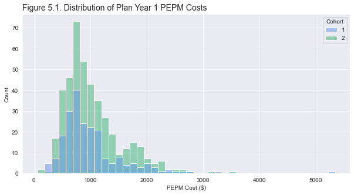

```
Statistic: 0.6872124860475861
p-value: 0.4921954680866031
```

```python
# Figure 5.1. Distribution of Plan Year 1 PEPM Costs
claims_py1 = claims.copy()
claims_py1['Cohort'] = [1 if py == 1 else 2 if py <= 3 else 10 for py in claims_py1['Plan Year'].values]
plt.figure(figsize=(10, 5))
sns.histplot(data=claims_py1.query('PEPM > 0 and Cohort < 3'), x='PEPM', hue='Cohort', palette=['cornflowerblue', 'mediumseagreen'])
plt.xlabel('PEPM Cost ($)')
plt.title('Figure 5.1. Distribution of Plan Year 1 PEPM Costs', loc='left', fontdict={'fontsize': 14})
plt.show()

cohort1 = claims_py1.query('Cohort == 1')['PEPM'].values
cohort2 = claims_py1.query('Cohort == 2')['PEPM'].values
score = stats.ttest_ind(cohort2, cohort1)
print(f'Statistic: {score[0]}')
print(f'p-value: {score[1]}')
```

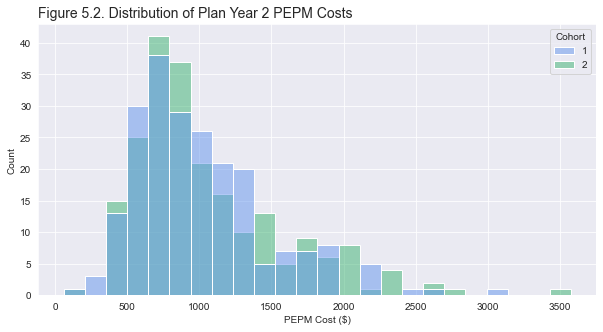

```
Statistic: 0.9793483353514498
p-value: 0.32795856424709857
```

```python
# Plan Year 2 Distribution of PEPM Costs
claims_py2 = claims.copy().query('`Plan Year` > 1')
claims_py2['Cohort'] = [1 if py == 2 else 2 if py <= 3 else 10 for py in claims_py2['Plan Year'].values]
plt.figure(figsize=(10, 5))
sns.histplot(data=claims_py2.query('PEPM > 0 and Cohort < 3'), x='PEPM', hue='Cohort', palette=['cornflowerblue', 'mediumseagreen'])
plt.xlabel('PEPM Cost ($)')
plt.title('Figure 5.2. Distribution of Plan Year 2 PEPM Costs', loc='left', fontdict={'fontsize': 14})
plt.show()

cohort1 = claims_py2.query('Cohort == 1')['PEPM'].values
cohort2 = claims_py2.query('Cohort == 2')['PEPM'].values
score = stats.ttest_ind(cohort2, cohort1)
print(f'Statistic: {score[0]}')
print(f'p-value: {score[1]}')
```

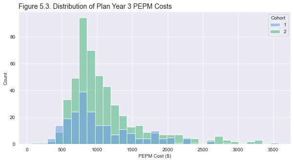

```
Statistic: 1.3089034290073263
p-value: 0.19098935580093418
```

```python
# Plan Year 3 Distribution of PEPM Costs
claims_py3 = claims.copy().query('`Plan Year` > 2')
claims_py3['Cohort'] = [1 if py == 3 else 2 if py <= 6 else 10 for py in claims_py3['Plan Year'].values]
plt.figure(figsize=(10, 5))
sns.histplot(data=claims_py3.query('PEPM > 0 and Cohort < 3'), x='PEPM', hue='Cohort', palette=['cornflowerblue', 'mediumseagreen'])
plt.xlabel('PEPM Cost ($)')
plt.title('Figure 5.3. Distribution of Plan Year 3 PEPM Costs', loc='left', fontdict={'fontsize': 14})
plt.show()

cohort1 = claims_py3.query('Cohort == 1')['PEPM'].values
cohort2 = claims_py3.query('Cohort == 2')['PEPM'].values
score = stats.ttest_ind(cohort2, cohort1)
print(f'Statistic: {score[0]}')
print(f'p-value: {score[1]}')
```

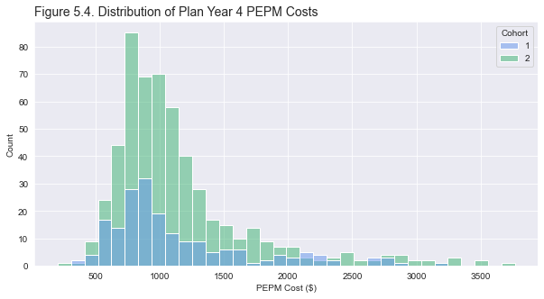

```
Statistic: 0.0907977145829931
p-value: 0.9276780306828769
```

```python
# Plan Year 4 Distribution of PEPM Costs
claims_py4 = claims.copy().query('`Plan Year` > 3')
claims_py4['Cohort'] = [1 if py == 4 else 2 if py <= 8 else 10 for py in claims_py4['Plan Year'].values]
plt.figure(figsize=(10, 5))
sns.histplot(data=claims_py4.query('PEPM > 0 and Cohort < 3'), x='PEPM', hue='Cohort', palette=['cornflowerblue', 'mediumseagreen'])
plt.xlabel('PEPM Cost ($)')
plt.title('Figure 5.4. Distribution of Plan Year 4 PEPM Costs', loc='left', fontdict={'fontsize': 14})
plt.show()

cohort1 = claims_py4.query('Cohort == 1')['PEPM'].values
cohort2 = claims_py4.query('Cohort == 2')['PEPM'].values
score = stats.ttest_ind(cohort2, cohort1)
print(f'Statistic: {score[0]}')
print(f'p-value: {score[1]}')
```

**Figures 5.1**, **5.2**, **5.3**, and **5.4** are all analagous to **Figure 4** above. While the p-value for **Figure 5.3** is particularly lower than its peers, it does not pose any problems. More specifically, the p-value indicates (as a probability) the chance that the observed difference in means between the two PEPM Cost distributions is incorrectly deemed statistically significant. While ~19% may sound worringly high, the gold standard in statistics is a p-value of 0.05 (or a 5% chance). If the p-value falls below the threshold, the phenomenon is generally deemed statistically significant. Since the lowest p-value is still nearly four times more than the traditional p-value cutoff, it is safe to say that the distributions generated are good approximations of the distributions of Plan Years 1, 2, 3, and 4. Next, these approximate distributions will be used to create a larger dataset with which to train the model.

## Modelling

### Data Formation

```python
# Python user-defined functions in order of appearance
def resample_plan_year_cohort(cohort_df, n):
    '''
    Generates resampled_plan_year_cohort DataFrame with n rows per month (i.e. 12n rows total)
    sampled with replacement from DataFrame cohort_df
    -----
    Inputs:

    cohort_df (DataFrame) - DataFrame with approximate distribution and filtered to exclude
                            negative and 0 values for PEPM Cost

    n (int) - Specifies the number of resamples
    -----
    Output:

    resampled_plan_year_cohort (DataFrame) - DataFrame generated from sampling with replacement
                                             with n rows per month (for a total of 12n rows)
    '''
    resampled_plan_year_cohort = pd.DataFrame(columns=cohort_df.columns)
    for month in np.arange(1, 13):
        month_df = cohort_df.query('`Plan Month` == @month')
        resampled = month_df.sample(n=n, replace=True, axis=0)
        resampled_plan_year_cohort = resampled_plan_year_cohort.append(resampled)
    return resampled_plan_year_cohort
```

```python
# Plan Year 1 Cohort
plan_year1_cohort = claims.query('PEPM > 0 and `Plan Year` <= 3')
cohort1 = resample_plan_year_cohort(plan_year1_cohort, 1000)

# Plan Year 2 Cohort
plan_year2_cohort = claims.query('PEPM > 0 and `Plan Year` > 1 and `Plan Year` <= 3')
cohort2 = resample_plan_year_cohort(plan_year2_cohort, 1000)

# Plan Year 3 Cohort
plan_year3_cohort = claims.query('PEPM > 0 and `Plan Year` > 2 and `Plan Year` <= 6')
cohort3 = resample_plan_year_cohort(plan_year3_cohort, 1000)

# Plan Year 4 Cohort
plan_year4_cohort = claims.query('PEPM > 0 and `Plan Year` > 3 and `Plan Year` <= 8')
cohort4 = resample_plan_year_cohort(plan_year4_cohort, 1000)

# Combining the four resampled cohorts
cohorts = [cohort1, cohort2, cohort3, cohort4]
expanded_claims = pd.DataFrame(columns=claims.columns)
for cohort in cohorts:
    expanded_claims = expanded_claims.append(cohort)
expanded_claims = expanded_claims.drop(['Month', 'Year', 'Plan Year'], axis=1)
plan_years = np.array([], dtype=int)
ones = np.ones(1000, dtype=int)
twos = ones + 1
threes = ones + 2
fours = ones + 3
for i in np.arange(0, 12):
    plan_month_group = np.array([], dtype=int)
    plan_month_group = np.append(plan_month_group, ones)
    plan_month_group = np.append(plan_month_group, twos)
    plan_month_group = np.append(plan_month_group, threes)
    plan_month_group = np.append(plan_month_group, fours)
    plan_years = np.append(plan_years, plan_month_group)
expanded_claims['Plan Year'] = plan_years
expanded_claims = expanded_claims[['Plan Month',
                                    'Plan Year',
                                    'Total Medical Claims',
                                    'Total Rx Claims',
                                    'Total Paid Claims',
                                    'Adjusted Total Expenses',
                                    'EE Count',
                                    'Member Count',
                                    'Client',
                                    'PEPM',
                                    'PMPM']].reset_index().drop('index', axis=1)
expanded_claims
```

|  | Plan Month | Plan Year | Total Medical Claims | Total Rx Claims | Total Paid Claims | Adjusted Total Expenses | EE Count | Member Count | Client | PEPM | PMPM |
| --- | --- | --- | --- | --- | --- | --- | --- | --- | --- | --- | --- |
| 0 | 1 | 1 | 4767.00 | 195529.47 | 200296.47 | 3.365825e+05 | 1093 | 2710 | Antelope Valley | 307.943705 | 124.200173 |
| 1 | 1 | 1 | 1324039.89 | 328595.73 | 1652635.62 | 1.842506e+06 | 2051 | 4973 | Enloe | 898.345256 | 370.501934 |
| 2 | 1 | 1 | 395033.06 | 138763.63 | 533796.69 | 6.264064e+05 | 1108 | 2598 | Marshall | 565.348718 | 241.111001 |
| 3 | 1 | 1 | 1263663.73 | 451547.90 | 1715211.63 | 1.931644e+06 | 3020 | 6623 | Huntington Memorial Hospital | 639.617053 | 291.656878 |
| 4 | 1 | 1 | 183404.43 | 85855.07 | 269259.50 | 3.253038e+05 | 976 | 2057 | CHA Hollywood Pres | 333.303064 | 158.144769 |
| ... | ... | ... | ... | ... | ... | ... | ... | ... | ... | ... | ... |
| 47995 | 12 | 4 | 1777329.15 | 484099.49 | 2261428.64 | 2.547698e+06 | 2706 | 6728 | Enloe | 941.499531 | 378.670887 |
| 47996 | 12 | 4 | 941860.47 | 73348.48 | 1015208.95 | 1.093209e+06 | 381 | 836 | Northern Inyo | 2869.313955 | 1307.665810 |
| 47997 | 12 | 4 | 11646247.11 | 2220784.24 | 13867031.35 | 1.443582e+07 | 16422 | 32659 | Prime Healthcare | 879.053854 | 442.016669 |
| 47998 | 12 | 4 | 2297491.03 | 894204.68 | 3191695.71 | 3.672852e+06 | 3048 | 5731 | CHLA | 1205.003773 | 640.874455 |
| 47999 | 12 | 4 | 315682.44 | 42450.61 | 358133.05 | 4.234171e+05 | 611 | 1433 | Dameron | 692.990387 | 295.476013 |

48000 rows × 11 columns

Now that `expanded_claims` has been constructed, some verification is necessary to ensure that the assumptions made in previous sections are valid.

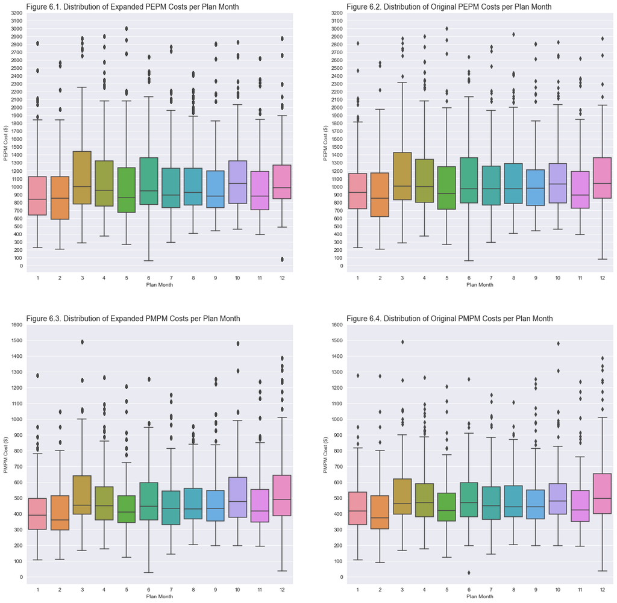

```python
plt.figure(figsize=(20, 20))

# Figure 6.1. Distribution of Expanded PEPM Costs per Plan Month
plt.subplot(2, 2, 1)
sns.boxplot(data=expanded_claims.query('PEPM < 3000'), x='Plan Month', y='PEPM')
plt.yticks(np.arange(0, 3300, 100))
plt.ylabel('PEPM Cost ($)')
plt.title('Figure 6.1. Distribution of Expanded PEPM Costs per Plan Month', loc='left', fontdict={'fontsize': 14})

# Figure 6.2. Distribution of Original PEPM Costs per Plan Month
plt.subplot(2, 2, 2)
sns.boxplot(data=claims.query('PEPM > 0 and PEPM < 3000'), x='Plan Month', y='PEPM')
plt.yticks(np.arange(0, 3300, 100))
plt.ylabel('PEPM Cost ($)')
plt.title('Figure 6.2. Distribution of Original PEPM Costs per Plan Month', loc='left', fontdict={'fontsize': 14})

# Figure 6.3. Distribution of Expanded PMPM Costs per Plan Month
plt.subplot(2, 2, 3)
sns.boxplot(data=expanded_claims.query('PMPM < 1500'), x='Plan Month', y='PMPM')
plt.yticks(np.arange(0, 1700, 100))
plt.ylabel('PMPM Cost ($)')
plt.title('Figure 6.3. Distribution of Expanded PMPM Costs per Plan Month', loc='left', fontdict={'fontsize': 14})

# Figure 6.4. Distribution of Original PMPM Costs per Plan Month
plt.subplot(2, 2, 4)
sns.boxplot(data=claims.query('PMPM > 0 and PMPM < 1500'), x='Plan Month', y='PMPM')
plt.yticks(np.arange(0, 1700, 100))
plt.ylabel('PMPM Cost ($)')
plt.title('Figure 6.4. Distribution of Original PMPM Costs per Plan Month', loc='left', fontdict={'fontsize': 14})

plt.show()
```

These distributions look great. Comparing **Figures 6.1** and **6.2** and **Figures 6.3** and **6.4**, the distributions look remarkably similar. This is precisely what was desired.

### Transforming the Data

```python
# Python user-defined functions in order of appearance
def calculate_year_avg_pepm(expanded_df, plan_year, n):
    '''
    Extracts the year average PEPM cost from expanded DataFrame expanded_df
    for the specified plan year plan_year
    -----
    Input:

    resampled_df (DataFrame) - DataFrame with bootstrapped data

    plan_year (int) - Int value specifying the renewal year to extract

    n (int) - Number of resamples
    -----
    Output:

    pepm_plan_year (NumPy Array) - NumPy Array of length n (where n is the number of resamples)
                                   with the yearly mean PEPM values
    '''
    plan_year = expanded_df.query('`Plan Year` == @plan_year')
    pepm_arr_plan_year = plan_year['PEPM'].values
    ee_arr_plan_year = plan_year['EE Count'].values
    pepm_arr_plan_year_split = np.split(pepm_arr_plan_year, 12)
    ee_arr_plan_year_split = np.split(ee_arr_plan_year, 12)
    ee_sums = np.zeros(n)
    for i in range(len(ee_arr_plan_year_split)):
        ee_sums = ee_sums + ee_arr_plan_year_split[i]
    ee_props = [ee_arr_plan_year_split[i] / ee_sums for i in range(len(ee_arr_plan_year_split))]
    weighted_totals = [np.multiply(ee_props[i], pepm_arr_plan_year_split[i]) for i in range(len(ee_props))]
    pepm_plan_year = np.zeros(n)
    for i in range(len(weighted_totals)):
        pepm_plan_year = pepm_plan_year + weighted_totals[i]
    return pepm_plan_year

def create_design_matrix(expanded_df, plan_year1, plan_year2, plan_year3, n, for_training=True, PMPM=False):
    '''
    Creates a design matrix matrix given the expanded DataFrame expanded_df, plan year 1 DataFrame plan_year1,
    plan year 2 DataFrame plan_year2, and plan year 3 DataFrame plan_year3. If specified, can also add PMPM
    features to the design matrix
    -----
    Inputs:

    expanded_df (DataFrame) - Expanded DataFrame used to calculate following year average PEPM Cost

    plan_year1 (DataFrame) - Filtered expanded DataFrame with data from plan year 1

    plan_year2 (DataFrame) - Filtered expanded DataFrame with data from plan year 2

    plan_year3 (DataFrame) - Filtered expanded DataFrame with data from plan year 3

    n (int) - Rows of data per month

    for_training (boolean) - Default value True; if False, creates design matrix without
                             Following Year Average PEPM column

    PMPM (boolean) - Default value False; if True includes PMPM value in design matrix matrix
    -----
    Output:

    matrix (DataFrame) - Design matrix as a DataFrame
    '''
    if for_training:
        actual_values = calculate_year_avg_pepm(expanded_df, 4, n)
    year1 = np.split(plan_year1['PEPM'].values, 12)
    year2 = np.split(plan_year2['PEPM'].values, 12)
    year3 = np.split(plan_year3['PEPM'].values, 12)
    if PMPM:
        year1_pmpm = np.split(plan_year1['PMPM'].values, 12)
        year2_pmpm = np.split(plan_year2['PMPM'].values, 12)
        year3_pmpm = np.split(plan_year3['PMPM'].values, 12)
        design_matrix = pd.DataFrame(data={'Month 1 PEPM': year1[0], 'Month 2 PEPM': year1[1],
                                           'Month 3 PEPM': year1[2], 'Month 4 PEPM': year1[3],
                                           'Month 5 PEPM': year1[4], 'Month 6 PEPM': year1[5],
                                           'Month 7 PEPM': year1[6], 'Month 8 PEPM': year1[7],
                                           'Month 9 PEPM': year1[8], 'Month 10 PEPM': year1[9],
                                           'Month 11 PEPM': year1[10], 'Month 12 PEPM': year1[11],
                                           'Month 13 PEPM': year2[0], 'Month 14 PEPM': year2[1],
                                           'Month 15 PEPM': year2[2], 'Month 16 PEPM': year2[3],
                                           'Month 17 PEPM': year2[4], 'Month 18 PEPM': year2[5],
                                           'Month 19 PEPM': year2[6], 'Month 20 PEPM': year2[7],
                                           'Month 21 PEPM': year2[8], 'Month 22 PEPM': year2[9],
                                           'Month 23 PEPM': year2[10], 'Month 24 PEPM': year2[11],
                                           'Month 25 PEPM': year3[0], 'Month 26 PEPM': year3[1],
                                           'Month 27 PEPM': year3[2], 'Month 28 PEPM': year3[3],
                                           'Month 29 PEPM': year3[4], 'Month 30 PEPM': year3[5],
                                           'Month 31 PEPM': year3[6], 'Month 32 PEPM': year3[7],
                                           'Month 33 PEPM': year3[8], 'Month 34 PEPM': year3[9],
                                           'Month 35 PEPM': year3[10], 'Month 36 PEPM': year3[11],
                                           'Month 1 PMPM': year1_pmpm[0], 'Month 2 PMPM': year1_pmpm[1],
                                           'Month 3 PMPM': year1_pmpm[2], 'Month 4 PMPM': year1_pmpm[3],
                                           'Month 5 PMPM': year1_pmpm[4], 'Month 6 PMPM': year1_pmpm[5],
                                           'Month 7 PMPM': year1_pmpm[6], 'Month 8 PMPM': year1_pmpm[7],
                                           'Month 9 PMPM': year1_pmpm[8], 'Month 10 PMPM': year1_pmpm[9],
                                           'Month 11 PMPM': year1_pmpm[10], 'Month 12 PMPM': year1_pmpm[11],
                                           'Month 13 PMPM': year2_pmpm[0], 'Month 14 PMPM': year2_pmpm[1],
                                           'Month 15 PMPM': year2_pmpm[2], 'Month 16 PMPM': year2_pmpm[3],
                                           'Month 17 PMPM': year2_pmpm[4], 'Month 18 PMPM': year2_pmpm[5],
                                           'Month 19 PMPM': year2_pmpm[6], 'Month 20 PMPM': year2_pmpm[7],
                                           'Month 21 PMPM': year2_pmpm[8], 'Month 22 PMPM': year2_pmpm[9],
                                           'Month 23 PMPM': year2_pmpm[10], 'Month 24 PMPM': year2_pmpm[11],
                                           'Month 25 PMPM': year3_pmpm[0], 'Month 26 PMPM': year3_pmpm[1],
                                           'Month 27 PMPM': year3_pmpm[2], 'Month 28 PMPM': year3_pmpm[3],
                                           'Month 29 PMPM': year3_pmpm[4], 'Month 30 PMPM': year3_pmpm[5],
                                           'Month 31 PMPM': year3_pmpm[6], 'Month 32 PMPM': year3_pmpm[7],
                                           'Month 33 PMPM': year3_pmpm[8], 'Month 34 PMPM': year3_pmpm[9],
                                           'Month 35 PMPM': year3_pmpm[10], 'Month 36 PMPM': year3_pmpm[11],
                                           'Following Year Average PEPM': actual_values.astype(float)})
    else:
        design_matrix = pd.DataFrame(data={'Month 1': year1[0], 'Month 2': year1[1],
                                           'Month 3': year1[2], 'Month 4': year1[3],
                                           'Month 5': year1[4], 'Month 6': year1[5],
                                           'Month 7': year1[6], 'Month 8': year1[7],
                                           'Month 9': year1[8], 'Month 10': year1[9],
                                           'Month 11': year1[10], 'Month 12': year1[11],
                                           'Month 13': year2[0], 'Month 14': year2[1],
                                           'Month 15': year2[2], 'Month 16': year2[3],
                                           'Month 17': year2[4], 'Month 18': year2[5],
                                           'Month 19': year2[6], 'Month 20': year2[7],
                                           'Month 21': year2[8], 'Month 22': year2[9],
                                           'Month 23': year2[10], 'Month 24': year2[11],
                                           'Month 25': year3[0], 'Month 26': year3[1],
                                           'Month 27': year3[2], 'Month 28': year3[3],
                                           'Month 29': year3[4], 'Month 30': year3[5],
                                           'Month 31': year3[6], 'Month 32': year3[7],
                                           'Month 33': year3[8], 'Month 34': year3[9],
                                           'Month 35': year3[10], 'Month 36': year3[11],
                                           'Following Year Average PEPM': actual_values.astype(float)})
    return design_matrix
```

Now that `expanded_claims` has been both created and validated, it is time to transform the data to the desired specs. Remember, the model is to take monthly PEPM/PMPM values to predict the following year's medical plan cost.

```python
plan_year1 = expanded_claims.query('`Plan Year` == 1')
plan_year2 = expanded_claims.query('`Plan Year` == 2')
plan_year3 = expanded_claims.query('`Plan Year` == 3')
design_matrix = create_design_matrix(expanded_claims, plan_year1, plan_year2, plan_year3, 1000)
design_matrix
```

|  | Month 1 | Month 2 | Month 3 | Month 4 | Month 5 | Month 6 | Month 7 | Month 8 | Month 9 | Month 10 | ... | Month 28 | Month 29 | Month 30 | Month 31 | Month 32 | Month 33 | Month 34 | Month 35 | Month 36 | Following Year Average PEPM |
| --- | --- | --- | --- | --- | --- | --- | --- | --- | --- | --- | --- | --- | --- | --- | --- | --- | --- | --- | --- | --- | --- |
| 0 | 307.943705 | 1447.483855 | 620.953067 | 1104.748120 | 551.749646 | 1270.926984 | 435.059322 | 1344.957322 | 1809.908190 | 836.400013 | ... | 2225.839365 | 1476.196388 | 1291.047661 | 1059.306452 | 828.848517 | 1015.711834 | 826.776137 | 1199.841702 | 695.419041 | 849.905109 |
| 1 | 898.345256 | 1447.483855 | 986.237859 | 653.828012 | 498.006966 | 484.485433 | 816.629079 | 1632.821306 | 1183.032702 | 537.818878 | ... | 533.108959 | 1958.491658 | 946.483291 | 810.266125 | 1795.830721 | 691.819292 | 1594.189156 | 1454.776062 | 755.902907 | 1214.921388 |
| 2 | 565.348718 | 587.120072 | 1345.291253 | 1221.549597 | 722.779376 | 902.911408 | 961.221509 | 332.492857 | 1061.825596 | 1459.345536 | ... | 655.728431 | 799.438519 | 540.977703 | 1277.814544 | 765.371724 | 953.483619 | 1047.242055 | 929.851789 | 1203.401890 | 1062.653172 |
| 3 | 639.617053 | 738.483945 | 476.514541 | 1221.549597 | 551.749646 | 1379.196353 | 1264.864778 | 820.982096 | 988.416138 | 882.876957 | ... | 737.168251 | 1476.196388 | 2621.597415 | 1277.814544 | 2762.686675 | 725.742900 | 829.765179 | 929.851789 | 861.038773 | 1158.697167 |
| 4 | 333.303064 | 639.062188 | 620.953067 | 591.971806 | 1344.957322 | 654.236182 | 1150.542565 | 2998.296325 | 691.412192 | 816.629079 | ... | 776.618893 | 563.686714 | 1011.037134 | 750.510817 | 1175.415168 | 1093.058552 | 968.636367 | 1131.276837 | 731.276693 | 1035.048479 |
| ... | ... | ... | ... | ... | ... | ... | ... | ... | ... | ... | ... | ... | ... | ... | ... | ... | ... | ... | ... | ... | ... |
| 995 | 593.838481 | 806.249597 | 1782.853885 | 596.386460 | 806.249597 | 999.417022 | 925.451302 | 986.259779 | 786.898101 | 811.523028 | ... | 368.576364 | 550.461998 | 2621.597415 | 1084.994029 | 698.288445 | 987.883676 | 665.924037 | 760.190761 | 731.276693 | 902.315540 |
| 996 | 435.059322 | 551.749646 | 986.237859 | 653.828012 | 443.697151 | 513.894667 | 812.119639 | 607.439074 | 794.672980 | 1346.174631 | ... | 2225.839365 | 678.306848 | 1491.320568 | 1925.291049 | 772.857322 | 1392.357859 | 956.088276 | 1467.074551 | 1036.574258 | 960.150204 |
| 997 | 1123.820680 | 915.769056 | 861.483801 | 1381.770637 | 290.505933 | 513.894667 | 596.386460 | 986.259779 | 753.156211 | 878.245448 | ... | 533.108959 | 1848.786371 | 2274.115509 | 1188.918973 | 801.182338 | 1121.850965 | 1708.238068 | 649.132236 | 1040.211610 | 946.205227 |
| 998 | 1839.863038 | 778.365457 | 729.662604 | 773.966918 | 498.006966 | 513.894667 | 592.362742 | 1131.264403 | 833.288530 | 1150.542565 | ... | 927.726551 | 678.306848 | 901.663523 | 1072.231257 | 553.158903 | 1491.320568 | 826.776137 | 872.096832 | 826.823600 | 1035.201755 |
| 999 | 1104.748120 | 778.365457 | 513.894667 | 599.668661 | 770.744479 | 805.285554 | 1817.434461 | 906.997174 | 1114.778080 | 1074.631429 | ... | 462.950120 | 411.944739 | 660.007852 | 1863.809237 | 844.864065 | 1571.870538 | 800.603988 | 1680.665558 | 691.819292 | 852.369119 |

1000 rows × 37 columns

Now that a design matrix has been created it can be used to train the model.

### Training the Model

```python
# Python user-defined functions in order of appearance
def create_test_matrix(data, first_py, PMPM=False):
    '''
    Given DataFrame data with three Plan Years worth of data, creates a test matrix to use for prediction
    -----
    Input:

    data (DataFrame) - DataFrame with three Plan Years worth of data

    first_py (int) - Indicates which plan year is the first

    PMPM (Boolean) - Default value False; indicates whether PMPM should be included
    -----
    Output:

    test_matrix (DataFrame) - Test matrix DataFrame for prediction
    '''
    year1 = np.split(data.query('`Plan Year` == @first_py')['PEPM'].values, 12)
    year2 = np.split(data.query('`Plan Year` == @first_py + 1')['PEPM'].values, 12)
    year3 = np.split(data.query('`Plan Year` == @first_py + 2')['PEPM'].values, 12)
    test_matrix = pd.DataFrame(data={'Month 1': year1[0], 'Month 2': year1[1],
                                     'Month 3': year1[2], 'Month 4': year1[3],
                                     'Month 5': year1[4], 'Month 6': year1[5],
                                     'Month 7': year1[6], 'Month 8': year1[7],
                                     'Month 9': year1[8], 'Month 10': year1[9],
                                     'Month 11': year1[10], 'Month 12': year1[11],
                                     'Month 13': year2[0], 'Month 14': year2[1],
                                     'Month 15': year2[2], 'Month 16': year2[3],
                                     'Month 17': year2[4], 'Month 18': year2[5],
                                     'Month 19': year2[6], 'Month 20': year2[7],
                                     'Month 21': year2[8], 'Month 22': year2[9],
                                     'Month 23': year2[10], 'Month 24': year2[11],
                                     'Month 25': year3[0], 'Month 26': year3[1],
                                     'Month 27': year3[2], 'Month 28': year3[3],
                                     'Month 29': year3[4], 'Month 30': year3[5],
                                     'Month 31': year3[6], 'Month 32': year3[7],
                                     'Month 33': year3[8], 'Month 34': year3[9],
                                     'Month 35': year3[10], 'Month 36': year3[11]})
    if PMPM:
        year1_pmpm = np.split(data.query('`Plan Year` == @first_py')['PMPM'].values, 12)
        year2_pmpm = np.split(data.query('`Plan Year` == @first_py + 1')['PMPM'].values, 12)
        year3_pmpm = np.split(data.query('`Plan Year` == @first_py + 2')['PMPM'].values, 12)
        test_matrix = pd.DataFrame(data={'Month 1 PEPM': year1[0], 'Month 2 PEPM': year1[1],
                                         'Month 3 PEPM': year1[2], 'Month 4 PEPM': year1[3],
                                         'Month 5 PEPM': year1[4], 'Month 6 PEPM': year1[5],
                                         'Month 7 PEPM': year1[6], 'Month 8 PEPM': year1[7],
                                         'Month 9 PEPM': year1[8], 'Month 10 PEPM': year1[9],
                                         'Month 11 PEPM': year1[10], 'Month 12 PEPM': year1[11],
                                         'Month 13 PEPM': year2[0], 'Month 14 PEPM': year2[1],
                                         'Month 15 PEPM': year2[2], 'Month 16 PEPM': year2[3],
                                         'Month 17 PEPM': year2[4], 'Month 18 PEPM': year2[5],
                                         'Month 19 PEPM': year2[6], 'Month 20 PEPM': year2[7],
                                         'Month 21 PEPM': year2[8], 'Month 22 PEPM': year2[9],
                                         'Month 23 PEPM': year2[10], 'Month 24 PEPM': year2[11],
                                         'Month 25 PEPM': year3[0], 'Month 26 PEPM': year3[1],
                                         'Month 27 PEPM': year3[2], 'Month 28 PEPM': year3[3],
                                         'Month 29 PEPM': year3[4], 'Month 30 PEPM': year3[5],
                                         'Month 31 PEPM': year3[6], 'Month 32 PEPM': year3[7],
                                         'Month 33 PEPM': year3[8], 'Month 34 PEPM': year3[9],
                                         'Month 35 PEPM': year3[10], 'Month 36 PEPM': year3[11],
                                         'Month 1 PMPM': year1_pmpm[0], 'Month 2 PMPM': year1_pmpm[1],
                                         'Month 3 PMPM': year1_pmpm[2], 'Month 4 PMPM': year1_pmpm[3],
                                         'Month 5 PMPM': year1_pmpm[4], 'Month 6 PMPM': year1_pmpm[5],
                                         'Month 7 PMPM': year1_pmpm[6], 'Month 8 PMPM': year1_pmpm[7],
                                         'Month 9 PMPM': year1_pmpm[8], 'Month 10 PMPM': year1_pmpm[9],
                                         'Month 11 PMPM': year1_pmpm[10], 'Month 12 PMPM': year1_pmpm[11],
                                         'Month 13 PMPM': year2_pmpm[0], 'Month 14 PMPM': year2_pmpm[1],
                                         'Month 15 PMPM': year2_pmpm[2], 'Month 16 PMPM': year2_pmpm[3],
                                         'Month 17 PMPM': year2_pmpm[4], 'Month 18 PMPM': year2_pmpm[5],
                                         'Month 19 PMPM': year2_pmpm[6], 'Month 20 PMPM': year2_pmpm[7],
                                         'Month 21 PMPM': year2_pmpm[8], 'Month 22 PMPM': year2_pmpm[9],
                                         'Month 23 PMPM': year2_pmpm[10], 'Month 24 PMPM': year2_pmpm[11],
                                         'Month 25 PMPM': year3_pmpm[0], 'Month 26 PMPM': year3_pmpm[1],
                                         'Month 27 PMPM': year3_pmpm[2], 'Month 28 PMPM': year3_pmpm[3],
                                         'Month 29 PMPM': year3_pmpm[4], 'Month 30 PMPM': year3_pmpm[5],
                                         'Month 31 PMPM': year3_pmpm[6], 'Month 32 PMPM': year3_pmpm[7],
                                         'Month 33 PMPM': year3_pmpm[8], 'Month 34 PMPM': year3_pmpm[9],
                                         'Month 35 PMPM': year3_pmpm[10], 'Month 36 PMPM': year3_pmpm[11]})
    return test_matrix

def prediction(data, classification, under, over, verbose=False):
    '''
    Given a singular row of 36 months of data (data), will return the predicted yearly average PEPM
    cost for the following year following the procedure outlined in this report
    -----
    Inputs:

    data (DataFrame) - DataFrame (1, 36) with 36 months of scaled actual PEPM values

    classification (sklearn.ensemble or sklearn.linear_model) - Sklearn classification model (either
                                                                Random Forest or a Logistic Regression
                                                                model) that predicts underestimates

    under (sklearn.linear_model or sklearn.neural_network) - Sklearn regression model (either Lasso Regression,
                                                             Ridge Regression, Linear Regression, or MLP Neural
                                                             Network) that predicts the average PEPM cost for the
                                                             following year for underestimated data

    over (sklearn.linear_model or sklearn.neural_network) - Skelarn regression model (either Lasso Regression,
                                                            Ridge Regression, Linear Regression, or MLP Neural
                                                            Network) that predicts the average PEPM cost for the
                                                            following year for overestimated data

    Y_scaler (sklearn.preprocessing._data.StandardScaler) - Fitted sklearn StandardScaler object to unscale prediction

    verbose (Boolean) - Default False; if True, prints 1 if underestimate and 0 if not
    -----
    Output:

    prediction (float) - Predicted average PEPM cost for the following year
    '''
    is_underestimate = classification.predict(data)
    if verbose:
        estimate = ['Underestimate' if value == 1 else 'Overestimate' for value in is_underestimate][0]
        print(estimate)
    if is_underestimate:
        prediction = under.predict(data)
    else:
        prediction = over.predict(data)
    return prediction
```

Considering the relatively large number of features included in the design matrix, a few models may be appropriate. In this section, two different approaches will be taken: a linear regression approach and a neural network approach.

The first approach is a Ridge Regression model (or an Ordinary Least Squares model with an L2 regularization term). At a high level, this is a linear model that allows for better generalizability. Ultiamtely, the key to creating a good model is to strike the optimal balance between model accuracy (how well the model can predict from its training data) and model generalizability (how well the model can predict from data it has never seen before). With a large number of features, the model in this project is particularly prone to overfitting to the training data (sacrificing generalizability in the process). Ridge Regression seeks to remedy this.

For a more sophisticated explanation for those more familiar with linear regression, think about the process behind linear regression. Under the hood, an OLS model is optimizing parameters that minimize some loss function (squared loss in this case). Adding L2 regularization, in effect, adds a penalty term to the loss function that penalizes the model proportional to the model's relative complexity in the hopes of preventing overfitting. Some hyperparameter, alpha, can also be tuned to allow for greater control of the strength of the regularization term&em; with larger values of alpha corresponding to a stronger regularization term.

The second approach will be a Multi-Layer Perceptron (MLP) Neural Network model. An MLP Neural Network is far more complex than a Ridge Regression model and functions by mimicking the natural learning process in the brain. Fundamentally, the model is comprised of various layers of nodes or perceptrons with each node in one layer connected to each of the nodes in the subsequent layer. Between layers, the signals fed into the model (e.g. the various features) undergoes a series of transformations determined by a series of hyperparameters that ultimately map to a singular value—in this specific case at least.

*Disclaimer: I have not taken a formal course on Deep Learning and Neural Networks and thus am not able to discuss them on a more in-depth basis. This is, however, a high level understanding of what they are and how they differ from linear models.*

Below, both models will be trained and their performance evaluated against each other.

```
Training MSE: 22229.717116708485
Validation MSE: 21162.555018187468
765.2750230512275
1227.6825774250406
Alpha: 10000
```

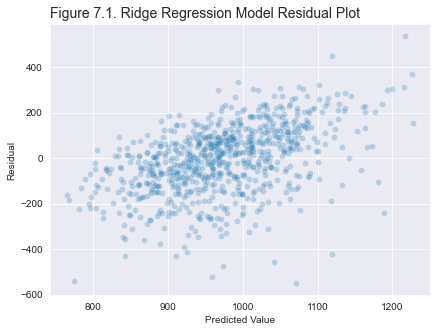

```
Correlation: 0.47505801588270896
```

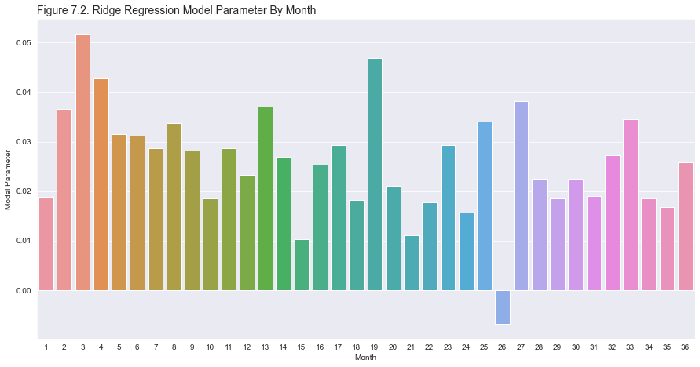

```
Training MSE: 24734.121436783345
Validation MSE: 25691.442069255645
674.2621944787977
1449.8383842432252
```

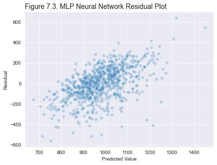

```
Correlation: 0.5603363834998542
```

```python
# Split into train and test sets
X = design_matrix.drop('Following Year Average PEPM', axis=1)
Y = design_matrix[['Following Year Average PEPM']]
X_train, X_test, Y_train, Y_test = model_selection.train_test_split(X, Y, test_size=0.2)

# Train and fit the model
model = linear_model.RidgeCV(alphas=np.arange(1, 10001), fit_intercept=False, cv=None)
model.fit(X_train, Y_train.values.flatten())

# Model Validation
training_predictions = model.predict(X_train)
validation_predictions = model.predict(X_test)
model_training_mse = np.mean((training_predictions - Y_train.values.flatten()) ** 2)
model_validation_mse = np.mean((validation_predictions - Y_test.values.flatten()) ** 2)
print(f'Training MSE: {model_training_mse}')
print(f'Validation MSE: {model_validation_mse}')
print(min(training_predictions.flatten()))
print(max(training_predictions.flatten()))
print(f'Alpha: {model.alpha_}')

# Plotting the residuals
residuals = training_predictions - Y_train.values.flatten()
residuals_df = pd.DataFrame(data={'Predicted Value': training_predictions, 'Residual': residuals}, dtype=float)

plt.figure(figsize=(15, 5))
plt.subplot(1, 2, 1)
sns.scatterplot(data=residuals_df, x='Predicted Value', y='Residual', alpha=0.25)
plt.title('Figure 7.1. Ridge Regression Model Residual Plot', loc='left', fontdict={'fontsize': 14})
plt.show()
correlation = residuals_df['Predicted Value'].corr(residuals_df['Residual'])
print(f'Correlation: {correlation}')

# Plotting model parameters
model_parameters = model.coef_.flatten()
coefficients_df = pd.DataFrame(data={'Month': np.arange(1, 37), 'Coefficients': model_parameters})

plt.figure(figsize=(15, 7.5))
sns.barplot(data=coefficients_df, x='Month', y='Coefficients')
plt.xlabel('Month')
plt.ylabel('Model Parameter')
plt.title('Figure 7.2. Ridge Regression Model Parameter By Month', loc='left', fontdict={'fontsize': 14})
plt.show()

# Train and fit a MLP Neural Network
neural_net = neural_network.MLPRegressor(hidden_layer_sizes=(36,18,9),
                                         activation='relu',
                                         alpha=0.001,
                                         max_iter=1000,
                                         early_stopping=True)
neural_net.fit(X_train, Y_train.values.flatten())

# Neural Network Validation
neural_network_training_predictions = neural_net.predict(X_train)
neural_network_validation_predictions = neural_net.predict(X_test)
neural_network_training_mse = np.mean((neural_network_training_predictions - Y_train.values.flatten()) ** 2)
neural_network_validation_mse = np.mean((neural_network_validation_predictions - Y_test.values.flatten()) ** 2)
print(f'Training MSE: {neural_network_training_mse}')
print(f'Validation MSE: {neural_network_validation_mse}')
print(min(neural_network_training_predictions.flatten()))
print(max(neural_network_training_predictions.flatten()))

# Plotting the residuals
neural_network_residuals = neural_network_training_predictions - Y_train.values.flatten()
neural_network_residuals_df = pd.DataFrame(data={'Predicted Value': neural_network_training_predictions,
                                                 'Residual': neural_network_residuals}, dtype=float)

plt.figure(figsize=(15, 5))
plt.subplot(1, 2, 1)
sns.scatterplot(data=neural_network_residuals_df, x='Predicted Value', y='Residual', alpha=0.25)
plt.title('Figure 7.3. MLP Neural Network Residual Plot', loc='left', fontdict={'fontsize': 14})
plt.show()
neural_network_correlation = neural_network_residuals_df['Predicted Value'] \
                                 .corr(neural_network_residuals_df['Residual'])
print(f'Correlation: {neural_network_correlation}')
```

**Figures 7.1** and **7.3** plot the residuals (or errors of the predicted values) against the predicted value itself. These plots are critical to interpreting the quality of a regression model.

Looking to both plots it is clear that both models have residuals that—while centered around zero—have a clear trend. With negative residuals, this indicates that both models have a tendency to underestimate values. To remedy this, a classification model can be utilized to identify datapoints that may be more prone to over/underestimation which may can be used to train a separate model to make better predictions for these data. Since the Ridge Regression model had better performance (lower MSE), this model will be used to build training data for a new classification model.

```python
# Add Underestimate label to training data
estimation = X_train.copy()
estimation['Underestimate'] = [1 if residual < 0 else 0 for residual in residuals_df['Residual'].values]
estimation
```

|  | Month 1 | Month 2 | Month 3 | Month 4 | Month 5 | Month 6 | Month 7 | Month 8 | Month 9 | Month 10 | ... | Month 28 | Month 29 | Month 30 | Month 31 | Month 32 | Month 33 | Month 34 | Month 35 | Month 36 | Underestimate |
| --- | --- | --- | --- | --- | --- | --- | --- | --- | --- | --- | --- | --- | --- | --- | --- | --- | --- | --- | --- | --- | --- |
| 235 | 1747.065226 | 673.225215 | 850.588610 | 594.536481 | 1391.845173 | 999.417022 | 797.842914 | 1781.540192 | 761.892292 | 898.465102 | ... | 1855.998373 | 1162.670475 | 391.061144 | 508.004663 | 1904.515471 | 987.883676 | 1669.309787 | 998.583770 | 881.966942 | 0 |
| 600 | 756.333005 | 262.300574 | 727.682069 | 639.617053 | 673.225215 | 861.483801 | 811.382128 | 1131.264403 | 761.892292 | 833.578781 | ... | 1072.231257 | 1162.670475 | 1093.058552 | 999.185395 | 828.848517 | 712.839782 | 1209.128083 | 839.386056 | 615.532467 | 1 |
| 355 | 2103.206342 | 867.366382 | 1289.258013 | 2032.877127 | 1277.835815 | 986.237859 | 1729.247637 | 1391.845173 | 1480.810411 | 592.362742 | ... | 1510.145745 | 811.730327 | 727.317420 | 1133.207724 | 811.730327 | 739.172328 | 826.776137 | 1231.275516 | 588.318148 | 0 |
| 778 | 773.966918 | 1238.367581 | 1379.196353 | 538.555826 | 603.557773 | 1270.926984 | 773.966918 | 915.783403 | 1276.993733 | 2814.879339 | ... | 607.674018 | 678.306848 | 841.659752 | 1133.207724 | 1199.841702 | 691.819292 | 861.997688 | 828.848517 | 826.823600 | 1 |
| 247 | 542.571954 | 1344.957322 | 476.514541 | 2467.401134 | 711.889838 | 2796.614031 | 882.876957 | 1382.918939 | 1111.880839 | 1175.745104 | ... | 761.120391 | 1476.196388 | 840.363715 | 810.266125 | 1795.830721 | 691.819292 | 1277.814544 | 802.956574 | 1203.309866 | 1 |
| ... | ... | ... | ... | ... | ... | ... | ... | ... | ... | ... | ... | ... | ... | ... | ... | ... | ... | ... | ... | ... | ... |
| 849 | 538.555826 | 658.930823 | 620.953067 | 1104.748120 | 1510.190543 | 667.416984 | 757.461786 | 948.213252 | 1266.194484 | 592.946100 | ... | 462.950120 | 591.305452 | 1291.047661 | 815.057577 | 1127.859191 | 953.483619 | 884.598194 | 695.050192 | 831.983866 | 1 |
| 574 | 773.165335 | 498.006966 | 629.462474 | 1118.556733 | 443.697151 | 563.919551 | 811.382128 | 1077.907728 | 649.853196 | 1459.345536 | ... | 1796.991864 | 924.121196 | 901.663523 | 900.412461 | 2762.686675 | 849.653799 | 884.598194 | 1009.920272 | 731.276693 | 1 |
| 742 | 1882.033827 | 722.779376 | 1495.060530 | 653.828012 | 1154.850060 | 784.180990 | 550.186267 | 747.605751 | 753.156211 | 1089.978008 | ... | 368.576364 | 550.461998 | 727.317420 | 855.872918 | 760.190761 | 2270.261938 | 1084.906065 | 839.386056 | 543.060827 | 0 |
| 609 | 1159.309037 | 1510.190543 | 476.514541 | 435.059322 | 443.697151 | 999.417022 | 905.351070 | 640.126646 | 756.453981 | 1459.345536 | ... | 1438.646010 | 1737.730464 | 552.941686 | 861.997688 | 847.481353 | 657.674832 | 829.765179 | 984.601840 | 831.983866 | 1 |
| 288 | 565.348718 | 641.503610 | 1098.713400 | 812.119639 | 1298.647023 | 1098.713400 | 728.053144 | 2179.617059 | 691.412192 | 1346.174631 | ... | 999.185395 | 891.917518 | 841.659752 | 1209.128083 | 1127.859191 | 885.453551 | 884.598194 | 1904.515471 | 1541.978883 | 0 |

800 rows × 37 columns

Although regression is in the name, Logistic Regression models are used primarily for binary classification. At a high level, Logistic Regression models predict the probability that a datapoint belongs to one label over the other. If the calculated probability is greater than some threshold (typically 0.5), the model predicts it belongs to label 1 and if not to label 0.

On the other hand, a Random Forest utilizes Decision Trees to classify data. Fundamentally, Decision Trees split data by some criteria (e.g. the value of a specific feature) until the training data is as pure as possible. A Random Forest takes a number of Decision Trees and has them "vote" to determine the label. Each Decision Tree is trained with a handle of the training data provided. The hope is to intentionally introduce randomness to increase the variance of individual Decision Trees. By combining many Decision Trees, a Random Forest (what is known as an ensemble model) hopes to account for that randomness.

Both will be trained and evaluated below.

```python
# Split into train and test sets
X_estimation = estimation.drop('Underestimate', axis=1)
Y_estimation = estimation[['Underestimate']]
X_train2, X_test2, Y_train2, Y_test2 = model_selection.train_test_split(X_estimation, Y_estimation, test_size=0.2)

# Train and fit the logistic regression model
classifier = linear_model.LogisticRegression(penalty='l2', solver='lbfgs', fit_intercept=False, max_iter=10000)
classifier.fit(X_train2, Y_train2.values.flatten())

# Logistic Regression Validation
training_predictions2 = classifier.predict(X_train2)
validation_predictions2 = classifier.predict(X_test2)

print(f'Logistic Regression Training Accuracy: {classifier.score(X_train2, Y_train2)}')
print(f'Logistic Regression Validation Accuracy: {classifier.score(X_test2, Y_test2)}')

# Train and fit the random forest model
forest = ensemble.RandomForestClassifier(n_estimators=5000, max_depth=3, min_samples_leaf=0.2, min_impurity_decrease=0.01, class_weight='balanced')
forest.fit(X_train2, Y_train2.values.flatten())

# Random Forest Validation
print(f'Random Forest Training Accuracy: {forest.score(X_train2, Y_train2)}')
print(f'Random Forest Validation Accuracy: {forest.score(X_test2, Y_test2)}')
print('\n')

# Confusion Matrices
print('Logistic Regression Confusion Matrix')
classifier_confusion = metrics.confusion_matrix(y_true=Y_test2.values.flatten(), y_pred=validation_predictions2)
display(classifier_confusion)
classifier_precision = classifier_confusion[1][1]/(classifier_confusion[1][1] + classifier_confusion[0][1])
print(f'Logistic Regression Precision: {classifier_precision}')
print('\n')
print('Random Forest Confusion Matrix')
forest_confusion = metrics.confusion_matrix(y_true=Y_test2.values.flatten(), y_pred=forest.predict(X_test2))
display(forest_confusion)
forest_precision = forest_confusion[1][1]/(forest_confusion[1][1] + forest_confusion[0][1])
print(f'Random Forest Precision: {forest_precision}')
```

```
Logistic Regression Training Accuracy: 0.553125
Logistic Regression Validation Accuracy: 0.40625
Random Forest Training Accuracy: 0.6828125
Random Forest Validation Accuracy: 0.55625


Logistic Regression Confusion Matrix
```

```
array([[45, 45],
       [50, 20]], dtype=int64)
```

```
Logistic Regression Precision: 0.3076923076923077


Random Forest Confusion Matrix
```

```
array([[58, 32],
       [39, 31]], dtype=int64)
```

```
Random Forest Precision: 0.49206349206349204
```

From the above, it is clear that the Random Forest model is the best suited for the task. Not only does it have the best validation accuracy, it also has higher precision—the proportion of predicted underestimates that are truly underestimates. This will ensure that the model will best split the data to isolate data prone to underestimation from that prone to overestimation. The predictions from this Random Forest model will be used to train a regression model for both the underestimated data and the overestimated data. Like before, a Ridge Regression model and an MLP Neural Network model will be trained for both sets of data.

```
Training Ridge Regression MSE: 15203.70741077411
Validation Ridge Regression MSE: 24988.549685380578
747.1580598361725
1250.375563824366
Alpha: 10000
```

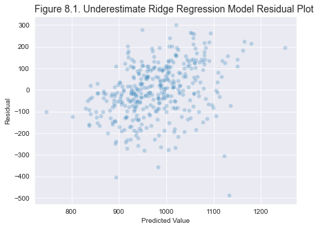

```
Correlation: 0.356478023868552
```

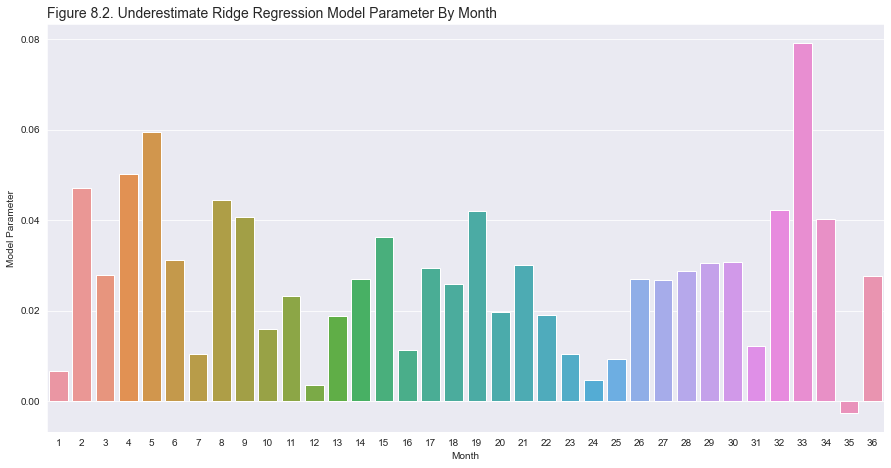

```
Training Neural Network MSE: 15976.84557091129
Validation Neural Network MSE: 31078.0438098689
618.2167108696516
1208.054722503117
```

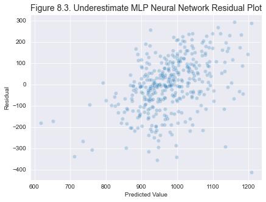

```
Correlation: 0.4260830258811177
Training Ridge Regression MSE: 20680.60725994785
Validation Ridge Regression MSE: 25819.70828254963
750.7965881994808
1267.4793906685998
Alpha: 10000
```

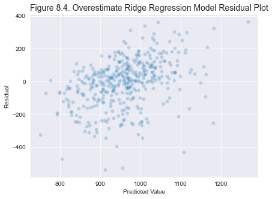

```
Correlation: 0.39706927284210347
```

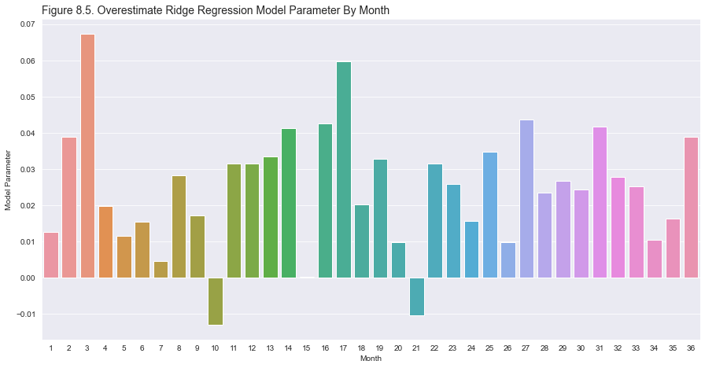

```
Overestimate Neural Network Training MSE: 101099.52121214487
Overestimate Neural Network Validation MSE: 102112.71709932554
179.77737318709384
1895.750293896821
```

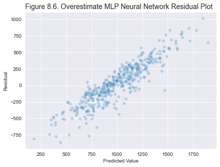

```
Correlation: 0.9061885362473711
```

```python
# Underestimate Modelling

underestimate_prediction_matrix = design_matrix.copy().drop('Following Year Average PEPM', axis=1)
underestimate_prediction_matrix['Underestimate'] = forest.predict(underestimate_prediction_matrix)
underestimate_matrix = underestimate_prediction_matrix.copy()
underestimate_matrix['Following Year Average PEPM'] = design_matrix['Following Year Average PEPM']
underestimate_matrix = underestimate_matrix.query('Underestimate == 1').reset_index().drop('index', axis=1) \
                                           .drop('Underestimate', axis=1)

# Split into train and test sets
X_underestimate = underestimate_matrix.drop('Following Year Average PEPM', axis=1)
Y_underestimate = underestimate_matrix[['Following Year Average PEPM']]
X_under_train, X_under_test, Y_under_train, Y_under_test = model_selection.train_test_split(X_underestimate, Y_underestimate, test_size=0.2)

# Train and fit the Ridge Regression model
under_model = linear_model.RidgeCV(alphas=np.arange(1, 10001), fit_intercept=False, cv=None)
under_model.fit(X_under_train, Y_under_train.values.flatten())

# Ridge Regression Model Validation
training_predictions_under = under_model.predict(X_under_train)
validation_predictions_under = under_model.predict(X_under_test)
under_model_training_mse = np.mean((training_predictions_under - Y_under_train.values.flatten()) ** 2)
under_model_validation_mse = np.mean((validation_predictions_under - Y_under_test.values.flatten()) ** 2)
print(f'Training Ridge Regression MSE: {under_model_training_mse}')
print(f'Validation Ridge Regression MSE: {under_model_validation_mse}')
print(min(training_predictions_under.flatten()))
print(max(training_predictions_under.flatten()))
print(f'Alpha: {under_model.alpha_}')

# Plotting the residuals
residuals_under = training_predictions_under - Y_under_train.values.flatten()
residuals_under_df = pd.DataFrame(data={'Predicted Value': training_predictions_under, 'Residual': residuals_under}, dtype=float)

plt.figure(figsize=(15, 5))
plt.subplot(1, 2, 1)
sns.scatterplot(data=residuals_under_df, x='Predicted Value', y='Residual', alpha=0.25)
plt.title('Figure 8.1. Underestimate Ridge Regression Model Residual Plot', loc='left', fontdict={'fontsize': 14})
plt.show()
under_correlation = residuals_under_df['Predicted Value'].corr(residuals_under_df['Residual'])
print(f'Correlation: {under_correlation}')

# Plotting Ridge Regression model parameters
under_model_parameters = under_model.coef_.flatten()
under_coefficients_df = pd.DataFrame(data={'Month': np.arange(1, 37), 'Coefficients': under_model_parameters})

plt.figure(figsize=(15, 7.5))
sns.barplot(data=under_coefficients_df, x='Month', y='Coefficients')
plt.xlabel('Month')
plt.ylabel('Model Parameter')
plt.title('Figure 8.2. Underestimate Ridge Regression Model Parameter By Month', loc='left', fontdict={'fontsize': 14})
plt.show()

# Train MLP Neural Network for regression
under_mlp = neural_network.MLPRegressor(hidden_layer_sizes=(18,9),
                                        activation='relu',
                                        alpha=0.0000001,
                                        max_iter=1000,
                                        early_stopping=True)
under_mlp.fit(X_under_train, Y_under_train.values.flatten())

# MLP Neural Network model validation
nn_under_training_predictions = under_mlp.predict(X_under_train)
nn_under_validation_predictions = under_mlp.predict(X_under_test)
nn_under_model_training_mse = np.mean((nn_under_training_predictions - Y_under_train.values.flatten()) ** 2)
nn_under_model_validation_mse = np.mean((nn_under_validation_predictions - Y_under_test.values.flatten()) ** 2)
print(f'Training Neural Network MSE: {nn_under_model_training_mse}')
print(f'Validation Neural Network MSE: {nn_under_model_validation_mse}')
print(min(nn_under_training_predictions.flatten()))
print(max(nn_under_training_predictions.flatten()))

# Plotting the residuals
nn_residuals_under = nn_under_training_predictions - Y_under_train.values.flatten()
nn_residuals_under_df = pd.DataFrame(data={'Predicted Value': nn_under_training_predictions, 'Residual': nn_residuals_under}, dtype=float)

plt.figure(figsize=(15, 5))
plt.subplot(1, 2, 1)
sns.scatterplot(data=nn_residuals_under_df, x='Predicted Value', y='Residual', alpha=0.25)
plt.title('Figure 8.3. Underestimate MLP Neural Network Residual Plot', loc='left', fontdict={'fontsize': 14})
plt.show()
nn_under_correlation = nn_residuals_under_df['Predicted Value'].corr(nn_residuals_under_df['Residual'])
print(f'Correlation: {nn_under_correlation}')

# Overestimation Modelling

overestimate_prediction_matrix = design_matrix.copy().drop('Following Year Average PEPM', axis=1)
overestimate_prediction_matrix['Overestimate'] = forest.predict(overestimate_prediction_matrix)
overestimate_matrix = overestimate_prediction_matrix.copy()
overestimate_matrix['Following Year Average PEPM'] = design_matrix['Following Year Average PEPM']
overestimate_matrix = overestimate_matrix.query('Overestimate == 0').reset_index().drop('index', axis=1) \
                                         .drop('Overestimate', axis=1)

# Split into train and test sets
X_overestimate = overestimate_matrix.drop('Following Year Average PEPM', axis=1)
Y_overestimate = overestimate_matrix[['Following Year Average PEPM']]
X_over_train, X_over_test, Y_over_train, Y_over_test = model_selection.train_test_split(X_overestimate, Y_overestimate, test_size=0.2)

# Train and fit the Ridge Regression model
over_model = linear_model.RidgeCV(alphas=np.arange(1, 10001), fit_intercept=False, cv=None)
over_model.fit(X_over_train, Y_over_train.values.flatten())

# Ridge Regression Model Validation
training_predictions_over = over_model.predict(X_over_train)
validation_predictions_over = over_model.predict(X_over_test)
over_model_training_mse = np.mean((training_predictions_over - Y_over_train.values.flatten()) ** 2)
over_model_validation_mse = np.mean((validation_predictions_over - Y_over_test.values.flatten()) ** 2)
print(f'Training Ridge Regression MSE: {over_model_training_mse}')
print(f'Validation Ridge Regression MSE: {over_model_validation_mse}')
print(min(training_predictions_over.flatten()))
print(max(training_predictions_over.flatten()))
print(f'Alpha: {over_model.alpha_}')

# Plotting the residuals
residuals_over = training_predictions_over - Y_over_train.values.flatten()
residuals_over_df = pd.DataFrame(data={'Predicted Value': training_predictions_over, 'Residual': residuals_over}, dtype=float)

plt.figure(figsize=(15, 5))
plt.subplot(1, 2, 1)
sns.scatterplot(data=residuals_over_df, x='Predicted Value', y='Residual', alpha=0.25)
plt.title('Figure 8.4. Overestimate Ridge Regression Model Residual Plot', loc='left', fontdict={'fontsize': 14})
plt.show()
over_correlation = residuals_over_df['Predicted Value'].corr(residuals_over_df['Residual'])
print(f'Correlation: {over_correlation}')

# Plotting Ridge Regression model parameters
over_model_parameters = over_model.coef_.flatten()
over_coefficients_df = pd.DataFrame(data={'Month': np.arange(1, 37), 'Coefficients': over_model_parameters})

plt.figure(figsize=(15, 7.5))
sns.barplot(data=over_coefficients_df, x='Month', y='Coefficients')
plt.xlabel('Month')
plt.ylabel('Model Parameter')
plt.title('Figure 8.5. Overestimate Ridge Regression Model Parameter By Month', loc='left', fontdict={'fontsize': 14})
plt.show()

# Train MLP Neural Network for regression
over_mlp = neural_network.MLPRegressor(hidden_layer_sizes=(18,9),
                                       activation='relu',
                                       alpha=0.0000001,
                                       max_iter=1000,
                                       early_stopping=True)
over_mlp.fit(X_under_train, Y_under_train.values.flatten())

# MLP Neural Network model validation
nn_over_training_predictions = over_mlp.predict(X_over_train)
nn_over_validation_predictions = over_mlp.predict(X_over_test)
nn_over_model_training_mse = np.mean((nn_over_training_predictions - Y_over_train.values.flatten()) ** 2)
nn_over_model_validation_mse = np.mean((nn_over_validation_predictions - Y_over_test.values.flatten()) ** 2)
print(f'Overestimate Neural Network Training MSE: {nn_over_model_training_mse}')
print(f'Overestimate Neural Network Validation MSE: {nn_over_model_validation_mse}')
print(min(nn_over_training_predictions.flatten()))
print(max(nn_over_training_predictions.flatten()))

# Plotting the residuals
nn_residuals_over = nn_over_training_predictions - Y_over_train.values.flatten()
nn_residuals_over_df = pd.DataFrame(data={'Predicted Value': nn_over_training_predictions, 'Residual': nn_residuals_over}, dtype=float)

plt.figure(figsize=(15, 5))
plt.subplot(1, 2, 1)
sns.scatterplot(data=nn_residuals_over_df, x='Predicted Value', y='Residual', alpha=0.25)
plt.title('Figure 8.6. Overestimate MLP Neural Network Residual Plot', loc='left', fontdict={'fontsize': 14})
plt.show()
nn_over_correlation = nn_residuals_over_df['Predicted Value'].corr(nn_residuals_over_df['Residual'])
print(f'Correlation: {nn_over_correlation}')
```

## Validating the Model

```python
# Plan Year 4 Historical Predictions
client_list = claims.query('Client != "Epic" and Client != "Marshall"')['Client'].unique()
first_three_list = [claims.query('Client == @client and (`Plan Year` == 1 or `Plan Year` == 2 or `Plan Year` == 3)') for client in client_list]
test_matrix_list = [create_test_matrix(client_data, 1) for client_data in first_three_list]
model_predictions = np.array([model.predict(test_matrix)[0] for test_matrix in test_matrix_list])
nn_prediction_list = np.array([prediction(test_matrix, forest, under_model, over_model)[0] for test_matrix in test_matrix_list])
prediction_list = np.array([prediction(test_matrix, forest, under_mlp, over_mlp)[0] for test_matrix in test_matrix_list])
actual_list = np.array([calculate_year_avg_pepm(claims.query('Client == @client'), 4, 1)[0] for client in client_list])
py4_MSE = np.mean((prediction_list - actual_list) ** 2)
nn_py4_MSE = np.mean((nn_prediction_list - actual_list) ** 2)
original_py4_MSE = np.mean((model_predictions - actual_list) ** 2)
predictions = pd.DataFrame(data={'Predicted Values': prediction_list,
                                 'Neural Network Predicted Values': nn_prediction_list,
                                 'Original Model Predicted Values': model_predictions,
                                 'Actual Values': actual_list,
                                 'Client': client_list})
display(predictions)
print(f'Combined MSE: {py4_MSE}')
print(f'Neural Network MSE: {nn_py4_MSE}')
print(f'Original MSE: {original_py4_MSE}')
```

|  | Predicted Values | Neural Network Predicted Values | Original Model Predicted Values | Actual Values | Client |
| --- | --- | --- | --- | --- | --- |
| 0 | 948.181312 | 962.478837 | 1013.265594 | 1294.984380 | Antelope Valley |
| 1 | 700.034312 | 654.454889 | 609.788828 | 759.745909 | Avanti/Pipeline |
| 2 | 844.343276 | 809.681250 | 776.753063 | 778.439771 | Beverly Hospital |
| 3 | 560.915828 | 524.407371 | 501.032234 | 839.512584 | CHA Hollywood Pres |
| 4 | 1069.713506 | 968.599788 | 1006.095069 | 1179.411289 | CHLA |
| 5 | 696.982554 | 669.066078 | 637.789061 | 632.044792 | Dameron |
| 6 | 811.708483 | 797.303752 | 831.265576 | 980.934774 | Enloe |
| 7 | 1943.057757 | 1699.458960 | 1769.023737 | 2134.359135 | Fairchild |
| 8 | 745.431231 | 832.273765 | 846.833562 | 922.635962 | Henry Mayo |
| 9 | 845.344197 | 796.644843 | 759.191388 | 805.821466 | Huntington Memorial Hospital |
| 10 | 1512.900576 | 1627.887947 | 1736.639784 | 2231.387449 | Northern Inyo |
| 11 | 662.051496 | 616.277976 | 583.727175 | 739.065477 | Prime Healthcare |
| 12 | 678.726388 | 618.085578 | 561.555774 | 792.159896 | Prospect Medical Holdings |
| 13 | 2035.463477 | 1609.794240 | 1705.630825 | 1983.837721 | Salinas Valley |
| 14 | 1184.108116 | 1179.747145 | 1242.630714 | 1171.634353 | Tahoe Forest |
| 15 | 922.171479 | 878.908422 | 847.709679 | 944.566036 | Torrance Health |

```
Combined MSE: 53661.82072883048
Neural Network MSE: 65794.32060574666
Original MSE: 51511.95672582195
```

```python
# Plan Year 5 Historical Predictions
client_list2 = claims.query('Client != "Epic" and Client != "Marshall" and Client != "CHA Hollywood Pres" and Client != "Northern Inyo" and Client != "Salinas Valley"')['Client'].unique()
first_three_list = [claims.query('Client == @client and (`Plan Year` == 2 or `Plan Year` == 3 or `Plan Year` == 4)') for client in client_list2]
test_matrix_list = [create_test_matrix(client_data, 2) for client_data in first_three_list]
model_predictions = np.array([model.predict(test_matrix)[0] for test_matrix in test_matrix_list])
prediction_list = np.array([prediction(test_matrix, forest, under_model, over_model)[0] for test_matrix in test_matrix_list])
nn_prediction_list = np.array([prediction(test_matrix, forest, under_mlp, over_mlp)[0] for test_matrix in test_matrix_list])
actual_list = np.array([calculate_year_avg_pepm(claims.query('Client == @client'), 5, 1)[0] for client in client_list2])
py5_MSE = np.mean((prediction_list - actual_list) ** 2)
nn_py5_MSE = np.mean((nn_prediction_list - actual_list) ** 2)
original_py5_MSE = np.mean((model_predictions - actual_list) ** 2)
predictions = pd.DataFrame(data={'Predicted Values': prediction_list,
                                 'Neural Network Predicted Values': nn_prediction_list,
                                 'Original Model Predicted Values': model_predictions,
                                 'Actual Values': actual_list,
                                 'Client': client_list2})
display(predictions)
print(f'Combined MSE: {py5_MSE}')
print(f'Neural Network MSE: {nn_py5_MSE}')
print(f'Original MSE: {original_py5_MSE}')
```

|  | Predicted Values | Neural Network Predicted Values | Original Model Predicted Values | Actual Values | Client |
| --- | --- | --- | --- | --- | --- |
| 0 | 1116.106185 | 1126.906321 | 1129.405610 | 1246.050814 | Antelope Valley |
| 1 | 699.960189 | 711.200693 | 634.706256 | 877.423241 | Avanti/Pipeline |
| 2 | 793.487099 | 804.697338 | 788.990979 | 967.043199 | Beverly Hospital |
| 3 | 951.975490 | 1220.162770 | 1015.421540 | 1251.922508 | CHLA |
| 4 | 647.469389 | 637.713426 | 603.845186 | 849.407154 | Dameron |
| 5 | 831.170872 | 862.284041 | 872.817391 | 1035.917435 | Enloe |
| 6 | 1739.009898 | 1742.016076 | 1770.223778 | 2213.431409 | Fairchild |
| 7 | 934.464843 | 956.027727 | 839.373682 | 843.197177 | Henry Mayo |
| 8 | 802.947346 | 842.241710 | 775.961080 | 1004.099845 | Huntington Memorial Hospital |
| 9 | 668.376303 | 703.459771 | 622.383513 | 758.247882 | Prime Healthcare |
| 10 | 687.176953 | 751.632823 | 635.381635 | 873.061295 | Prospect Medical Holdings |
| 11 | 1091.786803 | 1209.048180 | 1147.622884 | 1335.047505 | Tahoe Forest |
| 12 | 817.325668 | 1068.409233 | 874.037290 | 1029.380419 | Torrance Health |

```
Combined MSE: 51677.65017191957
Neural Network MSE: 33881.529993994096
Original MSE: 48443.10678834985
```

```python
# Plan Year 6 Historical Predictions
client_list3 = claims.query('Client != "Epic" and Client != "Marshall" and Client != "CHA Hollywood Pres" and Client != "Northern Inyo" and Client != "Salinas Valley" and Client != "Beverly Hospital" and Client != "CHLA"')['Client'].unique()
first_three_list = [claims.query('Client == @client and (`Plan Year` == 3 or `Plan Year` == 4 or `Plan Year` == 5)') for client in client_list3]
test_matrix_list = [create_test_matrix(client_data, 3) for client_data in first_three_list]
model_predictions = np.array([model.predict(test_matrix)[0] for test_matrix in test_matrix_list])
prediction_list = np.array([prediction(test_matrix, forest, under_model, over_model)[0] for test_matrix in test_matrix_list])
nn_prediction_list = np.array([prediction(test_matrix, forest, under_mlp, over_mlp)[0] for test_matrix in test_matrix_list])
actual_list = np.array([calculate_year_avg_pepm(claims.query('Client == @client'), 6, 1)[0] for client in client_list3])
py6_MSE = np.mean((prediction_list - actual_list) ** 2)
nn_py6_MSE = np.mean((nn_prediction_list - actual_list) ** 2)
original_py6_MSE = np.mean((model_predictions - actual_list) ** 2)
predictions = pd.DataFrame(data={'Predicted Values': prediction_list,
                                 'Neural Network Predicted Values': nn_prediction_list,
                                 'Original Model Predicted Values': model_predictions,
                                 'Actual Values': actual_list,
                                 'Client': client_list3})
display(predictions)
print(f'Predicted Values MSE: {py6_MSE}')
print(f'Neural Network MSE: {nn_py6_MSE}')
print(f'Original MSE: {original_py6_MSE}')
```

|  | Predicted Values | Neural Network Predicted Values | Original Model Predicted Values | Actual Values | Client |
| --- | --- | --- | --- | --- | --- |
| 0 | 1107.328750 | 1066.996501 | 1177.151654 | 1315.931645 | Antelope Valley |
| 1 | 785.353241 | 802.381080 | 719.439425 | 815.387330 | Avanti/Pipeline |
| 2 | 701.186241 | 751.023962 | 685.537568 | 747.456828 | Dameron |
| 3 | 841.115553 | 727.285746 | 882.410076 | 1137.423613 | Enloe |
| 4 | 1859.069131 | 1481.541633 | 1929.553526 | 2452.418010 | Fairchild |
| 5 | 901.514849 | 966.672722 | 887.801248 | 931.659229 | Henry Mayo |
| 6 | 857.826506 | 897.024992 | 821.077482 | 896.678063 | Huntington Memorial Hospital |
| 7 | 698.854908 | 750.386162 | 661.099666 | 842.884283 | Prime Healthcare |
| 8 | 790.677532 | 856.122491 | 747.306901 | 801.260753 | Prospect Medical Holdings |
| 9 | 1074.938821 | 1443.929817 | 1101.222165 | 1398.492114 | Tahoe Forest |
| 10 | 817.285815 | 822.111590 | 866.422468 | 945.892936 | Torrance Health |

```
Predicted Values MSE: 57356.42349559297
Neural Network MSE: 109376.6170386512
Original MSE: 46272.69708721688
```

```python
# Plan Year 7 Historical Predictions
client_list4 = claims.query('Client != "Epic" and Client != "Marshall" and Client != "CHA Hollywood Pres" and Client != "Northern Inyo" and Client != "Salinas Valley" and Client != "Beverly Hospital" and Client != "CHLA"')['Client'].unique()
first_three_list = [claims.query('Client == @client and (`Plan Year` == 4 or `Plan Year` == 5 or `Plan Year` == 6)') for client in client_list4]
test_matrix_list = [create_test_matrix(client_data, 4) for client_data in first_three_list]
model_predictions = np.array([model.predict(test_matrix)[0] for test_matrix in test_matrix_list])
prediction_list = np.array([prediction(test_matrix, forest, under_model, over_model)[0] for test_matrix in test_matrix_list])
nn_prediction_list = np.array([prediction(test_matrix, forest, under_mlp, over_mlp)[0] for test_matrix in test_matrix_list])
actual_list = np.array([calculate_year_avg_pepm(claims.query('Client == @client'), 7, 1)[0] for client in client_list4])
py7_MSE = np.mean((prediction_list - actual_list) ** 2)
nn_py7_MSE = np.mean((nn_prediction_list - actual_list) ** 2)
original_py7_MSE = np.mean((model_predictions - actual_list) ** 2)
predictions = pd.DataFrame(data={'Predicted Values': prediction_list,
                                 'Neural Network Predicted Values': nn_prediction_list,
                                 'Original Model Predicted Values': model_predictions,
                                 'Actual Values': actual_list,
                                 'Client': client_list4})
display(predictions)
print(f'Predicted Values MSE: {py7_MSE}')
print(f'Neural Network MSE: {nn_py7_MSE}')
print(f'Original MSE: {original_py7_MSE}')
```

|  | Predicted Values | Neural Network Predicted Values | Original Model Predicted Values | Actual Values | Client |
| --- | --- | --- | --- | --- | --- |
| 0 | 1174.460883 | 1171.525945 | 1212.078149 | 1319.483269 | Antelope Valley |
| 1 | 811.675016 | 864.180295 | 757.615902 | 712.878027 | Avanti/Pipeline |
| 2 | 701.704393 | 729.604004 | 692.982914 | 918.272041 | Dameron |
| 3 | 926.140107 | 785.764096 | 944.708423 | 1223.753275 | Enloe |
| 4 | 2082.057446 | 1920.942340 | 2124.057917 | 2336.835668 | Fairchild |
| 5 | 905.490862 | 870.844548 | 832.379647 | 926.853781 | Henry Mayo |
| 6 | 834.271025 | 918.811524 | 827.395670 | 1035.579100 | Huntington Memorial Hospital |
| 7 | 777.896395 | 805.896901 | 723.595852 | 816.691493 | Prime Healthcare |
| 8 | 813.268855 | 868.701444 | 771.426865 | 895.584091 | Prospect Medical Holdings |
| 9 | 1294.042317 | 1644.413975 | 1241.425724 | 1644.965060 | Tahoe Forest |
| 10 | 849.228740 | 1050.155841 | 897.580673 | 961.426961 | Torrance Health |

```
Predicted Values MSE: 37834.25546277725
Neural Network MSE: 42787.74315066527
Original MSE: 39154.61740762532
```

```python
# Plan Year 8 Historical Predictions
client_list5 = claims.query('Client != "Epic" and Client != "Marshall" and Client != "CHA Hollywood Pres" and Client != "Northern Inyo" and Client != "Salinas Valley" and Client != "Beverly Hospital" and Client != "CHLA" and Client != "Avanti/Pipeline" and Client != "Enloe" and Client != "Huntington Memorial Hospital" and Client != "Prospect Medical Holdings" and Client != "Tahoe Forest"')['Client'].unique()
first_three_list = [claims.query('Client == @client and (`Plan Year` == 5 or `Plan Year` == 6 or `Plan Year` == 7)') for client in client_list5]
test_matrix_list = [create_test_matrix(client_data, 5) for client_data in first_three_list]
model_predictions = np.array([model.predict(test_matrix)[0] for test_matrix in test_matrix_list])
prediction_list = np.array([prediction(test_matrix, forest, under_model, over_model)[0] for test_matrix in test_matrix_list])
nn_prediction_list = np.array([prediction(test_matrix, forest, under_mlp, over_mlp)[0] for test_matrix in test_matrix_list])
actual_list = np.array([calculate_year_avg_pepm(claims.query('Client == @client'), 8, 1)[0] for client in client_list5])
py8_MSE = np.mean((prediction_list - actual_list) ** 2)
nn_py8_MSE = np.mean((nn_prediction_list - actual_list) ** 2)
original_py8_MSE = np.mean((model_predictions - actual_list) ** 2)
predictions = pd.DataFrame(data={'Predicted Values': prediction_list,
                                 'Neural Network Predicted Values': nn_prediction_list,
                                 'Original Model Predicted Values': model_predictions,
                                 'Actual Values': actual_list,
                                 'Client': client_list5})
display(predictions)
print(f'Predicted Values MSE: {py8_MSE}')
print(f'Neural Network MSE: {nn_py8_MSE}')
print(f'Original MSE: {original_py8_MSE}')
```

|  | Predicted Values | Neural Network Predicted Values | Original Model Predicted Values | Actual Values | Client |
| --- | --- | --- | --- | --- | --- |
| 0 | 1136.863873 | 1110.901211 | 1210.216238 | 1561.734835 | Antelope Valley |
| 1 | 837.705299 | 862.688675 | 814.442635 | 1022.715639 | Dameron |
| 2 | 2031.850184 | 1904.721175 | 2117.359881 | 2570.400823 | Fairchild |
| 3 | 869.518138 | 899.426386 | 835.245193 | 824.657295 | Henry Mayo |
| 4 | 786.981548 | 831.490667 | 748.439797 | 920.782757 | Prime Healthcare |
| 5 | 858.617069 | 1036.698482 | 907.070020 | 1066.047820 | Torrance Health |

```
Predicted Values MSE: 94620.62122743168
Neural Network MSE: 114402.30972695122
Original MSE: 71212.86739033448
```

```python
# Plan Year 9 Historical Predictions
client_list6 = claims.query('Client != "Epic" and Client != "Marshall" and Client != "CHA Hollywood Pres" and Client != "Northern Inyo" and Client != "Salinas Valley" and Client != "Beverly Hospital" and Client != "CHLA" and Client != "Avanti/Pipeline" and Client != "Enloe" and Client != "Huntington Memorial Hospital" and Client != "Prospect Medical Holdings" and Client != "Tahoe Forest" and Client != "Fairchild" and Client != "Henry Mayo"')['Client'].unique()
first_three_list = [claims.query('Client == @client and (`Plan Year` == 6 or `Plan Year` == 7 or `Plan Year` == 8)') for client in client_list6]
test_matrix_list = [create_test_matrix(client_data, 6) for client_data in first_three_list]
model_predictions = np.array([model.predict(test_matrix)[0] for test_matrix in test_matrix_list])
prediction_list = np.array([prediction(test_matrix, forest, under_model, over_model)[0] for test_matrix in test_matrix_list])
nn_prediction_list = np.array([prediction(test_matrix, forest, under_mlp, over_mlp)[0] for test_matrix in test_matrix_list])
actual_list = np.array([calculate_year_avg_pepm(claims.query('Client == @client'), 9, 1)[0] for client in client_list6])
py9_MSE = np.mean((prediction_list - actual_list) ** 2)
nn_py9_MSE = np.mean((nn_prediction_list - actual_list) ** 2)
original_py9_MSE = np.mean((model_predictions - actual_list) ** 2)
predictions = pd.DataFrame(data={'Predicted Values': prediction_list,
                                 'Neural Network Predicted Values': nn_prediction_list,
                                 'Original Model Predicted Values': model_predictions,
                                 'Actual Values': actual_list,
                                 'Client': client_list6})
display(predictions)
print(f'Predicted Values MSE: {py9_MSE}')
print(f'Neural Network MSE: {nn_py9_MSE}')
print(f'Original MSE: {original_py9_MSE}')
```

|  | Predicted Values | Neural Network Predicted Values | Original Model Predicted Values | Actual Values | Client |
| --- | --- | --- | --- | --- | --- |
| 0 | 1272.976154 | 1367.846237 | 1302.446083 | 1599.365944 | Antelope Valley |
| 1 | 888.549705 | 905.572455 | 843.541169 | 1157.420117 | Dameron |
| 2 | 864.437722 | 920.284777 | 796.584788 | 914.276404 | Prime Healthcare |
| 3 | 903.969212 | 994.246758 | 929.375044 | 1049.281601 | Torrance Health |

```
Predicted Values MSE: 50605.29469734833
Neural Network MSE: 30023.388540240783
Original MSE: 53727.57426073433
```

```python
# Plan Year 10 Historical Predictions
first_three_list = [claims.query('Client == @client and (`Plan Year` == 7 or `Plan Year` == 8 or `Plan Year` == 9)') for client in client_list6]
test_matrix_list = [create_test_matrix(client_data, 7) for client_data in first_three_list]
model_predictions = np.array([model.predict(test_matrix)[0] for test_matrix in test_matrix_list])
prediction_list = np.array([prediction(test_matrix, forest, under_model, over_model)[0] for test_matrix in test_matrix_list])
nn_prediction_list = np.array([prediction(test_matrix, forest, under_mlp, over_mlp)[0] for test_matrix in test_matrix_list])
actual_list = np.array([calculate_year_avg_pepm(claims.query('Client == @client'), 10, 1)[0] for client in client_list6])
py10_MSE = np.mean((prediction_list - actual_list) ** 2)
nn_py10_MSE = np.mean((nn_prediction_list - actual_list) ** 2)
original_py10_MSE = np.mean((model_predictions - actual_list) ** 2)
predictions = pd.DataFrame(data={'Predicted Values': prediction_list,
                                 'Neural Network Predicted Values': nn_prediction_list,
                                 'Original Model Predicted Values': model_predictions,
                                 'Actual Values': actual_list,
                                 'Client': client_list6})
display(predictions)
print(f'Predicted Values MSE: {py10_MSE}')
print(f'Neural Network MSE: {nn_py10_MSE}')
print(f'Original MSE: {original_py10_MSE}')
```

|  | Predicted Values | Neural Network Predicted Values | Original Model Predicted Values | Actual Values | Client |
| --- | --- | --- | --- | --- | --- |
| 0 | 1345.066825 | 1382.850943 | 1392.792525 | 1266.928222 | Antelope Valley |
| 1 | 998.784340 | 1060.122971 | 941.180078 | 1038.074140 | Dameron |
| 2 | 861.021503 | 940.687134 | 823.507042 | 920.893849 | Prime Healthcare |
| 3 | 878.576641 | 956.190212 | 939.581742 | 1062.023598 | Torrance Health |

```
Predicted Values MSE: 11221.70336779696
Neural Network MSE: 6379.177002677565
Original MSE: 12426.620027321846
```

```python
# Plan Year 11 Historical Predictions
first_three_list = [claims.query('Client == @client and (`Plan Year` == 8 or `Plan Year` == 9 or `Plan Year` == 10)') for client in client_list6]
test_matrix_list = [create_test_matrix(client_data, 8) for client_data in first_three_list]
model_predictions = np.array([model.predict(test_matrix)[0] for test_matrix in test_matrix_list])
prediction_list = np.array([prediction(test_matrix, forest, under_model, over_model)[0] for test_matrix in test_matrix_list])
nn_prediction_list = np.array([prediction(test_matrix, forest, under_mlp, over_mlp)[0] for test_matrix in test_matrix_list])
actual_list = np.array([calculate_year_avg_pepm(claims.query('Client == @client'), 11, 1)[0] for client in client_list6])
py11_MSE = np.mean((prediction_list - actual_list) ** 2)
nn_py11_MSE = np.mean((nn_prediction_list - actual_list) ** 2)
original_py11_MSE = np.mean((model_predictions - actual_list) ** 2)
predictions = pd.DataFrame(data={'Predicted Values': prediction_list,
                                 'Neural Network Predicted Values': nn_prediction_list,
                                 'Original Model Predicted Values': model_predictions,
                                 'Actual Values': actual_list,
                                 'Client': client_list6})
display(predictions)
print(f'Predicted Values MSE: {py11_MSE}')
print(f'Neural Network MSE: {nn_py11_MSE}')
print(f'Original MSE: {original_py11_MSE}')
```

|  | Predicted Values | Neural Network Predicted Values | Original Model Predicted Values | Actual Values | Client |
| --- | --- | --- | --- | --- | --- |
| 0 | 1354.912931 | 2039.597381 | 1411.401673 | 1266.928222 | Antelope Valley |
| 1 | 970.057035 | 1154.312004 | 989.224653 | 1444.641882 | Dameron |
| 2 | 921.571788 | 981.388061 | 871.780133 | 951.959321 | Prime Healthcare |
| 3 | 983.679294 | 1214.067199 | 998.061455 | 1434.575063 | Torrance Health |

```
Predicted Values MSE: 109300.62075722024
Neural Network MSE: 182699.7092062607
Original MSE: 106312.56578824003
```

## Conclusion

Comparing performance on historical data, it becomes immediately obvious that this model falls short of its original goal to predict yearly healthcare costs from 36 months of claims experience data. Although there was not enough time to conduct a full analysis on this model's specific shortcomings, there are some indications within the report itself. The first, most obvious, is the shape of the residual plots (both of the original Ridge Regression model and the subsequent under and overestimation models). Each featured some sort of positive correlation which indicates the features used to train the model do not account for all of the observed variance in the data. A more careful analysis of data available in Mede to create a more complex model would likely result in a better model. Second is a lack of data. Although the original `claims` data included some 1500 rows of data, the granularity was monthly. Given 36 months of data were required to predict, this reduced the number of unique datapoints to about 40. While the statistical methods applied are sound, having a more representative data sample is always better.

Overall, although the final model's utility is perhaps less than anticipated, as noted at the beginning of the report, this analysis is just a starting point. During lunch with Mitch at some point during my time here, he brought up the need for more advanced analytics in the insurance industry. It was a sentiment echoed by Ju at the June Healthcare meeting where I was first introduced to the rest of the team and one I wholeheartedly agree with. Although this model is not one that can necessarily be used, I have no doubt that with more work it could be refined into a model that outperforms current models/procedures for calculating renewl projections across the board. It is my hope that this analysis/report demonstrates the value that Machine Learning driven algorithms have in this industry and serves as a starting point for bringing more advanced analytics to Keenan. As I expressed in my final reflections email, for better or worse the world is continually finding new applications for more powerful predictive modelling and Keenan/AP must keep up to continue to stay ahead of its competitors.